# Computational Statistics: Final Assignment (Group C)

Zhuoyan Jiang, Kalpa Korottage Don, Elsa Mattila

2026-10-24

# Task 1: Time series bootstrap and signal dimension

## Part A: Whitening and Autocovariance Matrices

### Overview

This report implements Part A of the assignment: the preprocessing and matrix computations required by the time-series version of the ladle estimator of Nordhausen and Virta (2018). The report has two parts.

- **Section 1** defines the generic functions: centering, whitening, autocovariance estimation, symmetrization, and the AMUSE / SOBI diagonalizers.
- **Section 2** applies these functions to the course data `timeseries.dat` and verifies the implementation numerically.

All computations are implemented directly in R. The only ready-made routines used are `JADE::rjd()` for joint diagonalization (as permitted by the assignment) and `JADE::SOBI()` for an independent verification step. The functions defined here are written so that they can be re-applied inside a bootstrap loop in Part C, where each bootstrap sample must be re-centered, re-whitened, and re-diagonalized.

### 1. Generic functions

#### 1.1 Conventions

The sample size is $T$ (called $n$ in the assignment) and the dimension is $p$.

**Input convention:** every function that takes data expects a numeric $T \times p$ matrix whose rows are the time points, in time order, and whose columns are the variables. This matters in Part C, where every bootstrap sample is again a $T \times p$ matrix: a transposed input would give a wrong result without any error message. The following conventions are used consistently.

- **Centering.** Column-wise subtraction of the sample mean:
  $$\bar{x} = \frac{1}{T}\sum_{t=1}^{T}
  x_t, \qquad \tilde{x}_t = x_t - \bar{x}.$$
- **Scaling.** No additional marginal standardization (each column is not divided by its standard deviation first). Whitening uses the full sample covariance matrix, not only the column standard deviations, so it removes both the differences in scale and the contemporaneous correlation between columns. All scaling is absorbed into the whitening step. The whitening matrix is the symmetric inverse square root
  $$\hat{\Sigma}^{-1/2} = V
  D^{-1/2} V^\top,$$
  computed from the eigendecomposition $\hat{\Sigma} = V D V^\top$ of the sample covariance.
- **Lagging.** For a lag $\tau \ge 1$, the pairs $(x_t, x_{t+\tau})$, with $t = 1, \dots, T-\tau$, are used. No circular wrap-around in Part A.
- **Normalization.** The $1/T$ normalization is used throughout for the sample covariance and the autocovariance matrices:
  $$\hat{\Sigma} = \frac{1}{T}\sum_{t=1}^{T}
  \tilde{x}_t \tilde{x}_t^{\top}, \qquad \hat{\Sigma}_\tau =
  \frac{1}{T}\sum_{t=1}^{T-\tau} \hat{x}_t^{st}
  \hat{x}_{t+\tau}^{st\top}.$$
  Here $\hat{x}_t^{st}$ denotes the *whitened* series, so the autocovariance is estimated on the whitened data. The $1/T$ normalization is the same convention as R’s `acf(..., type = "covariance", demean = FALSE)`.
- **Symmetrization.** Under the model, $\Sigma_\tau$ is symmetric. The finite-sample estimate $\hat{\Sigma}_\tau$ is in general not symmetric, and its antisymmetric part is purely sampling noise. That part is removed:
  $$\tilde{\Sigma}_\tau =
  \frac{1}{2}\left(\hat{\Sigma}_\tau +
  \hat{\Sigma}_\tau^{\top}\right).$$
  Under the model, symmetrization removes sampling noise and does not remove signal.
- **Definition of $\Lambda$ and ordering.** Let $\tilde{\Sigma}_\tau$ be the symmetrized autocovariance matrix of the whitened series. The vector `Lambda` returned by these functions contains the diagonal elements of the matrix $\Lambda$ in the paper, that is, the values $\lambda_j^2$:
  - AMUSE (one lag $\tau$): $\lambda_j^2 = \left(u_j^\top \tilde{\Sigma}_\tau u_j\right)^2$.
  - SOBI (lag set $\mathcal{T}$): $\lambda_j^2 = \sum_{\tau \in \mathcal{T}} \left(v_j^\top \tilde{\Sigma}_\tau v_j\right)^2$.

  Here $u_j$ and $v_j$ are the columns of the estimated orthogonal matrix that belong to $\lambda_j^2$. In both cases the columns are ordered so that $\lambda_0^2 \ge \lambda_1^2 \ge \dots \ge \lambda_{p-1}^2$. The paper indexes these values from $0$ to $p-1$, so `Lambda[k + 1]` in R is $\lambda_k^2$. Part C uses the same sorted `Lambda` and the same column order. In the theory the orthogonal matrix is called $U$. In the code it is called `U` for AMUSE and `V` for SOBI (`V` is the name used by `rjd()`).

#### 1.2 Why whitening

In the second-order source separation (SOS) model

$$x_t = \mu + \Omega z_t, \qquad
\operatorname{Cov}(z_t) = I_p,$$

the covariance of $x_t$ is $\Sigma = \Omega\Omega^\top$, so the matrix $\Sigma^{-1/2}\Omega$ is orthogonal. The whitened series is therefore

$$x_t^{st} = \Sigma^{-1/2}(x_t - \mu) = U
z_t, \qquad U^\top U = I_p.$$

This has three consequences.

1. The unknown mixing matrix $\Omega$ reduces to an **orthogonal** matrix $U$.
2. The lag-$\tau$ autocovariance becomes
   $$\Sigma_\tau = U \, D_\tau \,
   U^\top, \qquad D_\tau = \operatorname{Cov}(z_t, z_{t+\tau}),$$
   If the component processes are mutually independent (assumptions (A1) and (A2) of Nordhausen and Virta, 2018), or at least uncorrelated across components at every lag, then $D_\tau$ is diagonal. The condition $\operatorname{Cov}(z_t) = I_p$ alone is not enough, because it only describes the components at the same time point. The diagonal form of $D_\tau$ is the condition that lets all the whitened lagged autocovariance matrices share the same diagonalizing matrix $U$. So a single lag can be diagonalized by `eigen()` (AMUSE), and a set of lags can be jointly diagonalized by an orthogonal matrix (SOBI).
3. Whitening removes scale and contemporaneous correlation; what is left in $\tilde{\Sigma}_\tau$ is the serial dependence that distinguishes signal components from white noise.

#### 1.3 Functions

```r
center_series <- function(X) {
  # Subtract the column means
  mu_hat <- colMeans(X)
  Xc <- sweep(X, 2, mu_hat, FUN = "-")
  list(mu = mu_hat, Xc = Xc)
}

whiten_series <- function(Xc) {
  Tn <- nrow(Xc)
  p <- ncol(Xc)

  # Sample covariance (1/T) and its eigendecomposition, which must not be singular
  S <- crossprod(Xc) / Tn
  eig <- eigen(S, symmetric = TRUE)
  stopifnot(min(eig$values) > 1e-10 * max(eig$values))

  # Symmetric inverse square root and whitened data
  D_inv_sqrt <- diag(1 / sqrt(eig$values), nrow = p)
  S_inv_sq <- eig$vectors %*% D_inv_sqrt %*% t(eig$vectors)

  Xw <- Xc %*% S_inv_sq

  list(S = S, eig = eig, S_inv_sq = S_inv_sq, Xw = Xw)
}

# Lag-tau autocovariance of the whitened series: (1/T) * sum_t x_t x_{t+tau}'
autocov_raw <- function(Xw, tau) {
  # The lag must be valid
  stopifnot(tau >= 1, tau < nrow(Xw))
  Tn <- nrow(Xw)
  # Pairs (x_t, x_{t+tau}) for t = 1, ..., T - tau
  A <- Xw[1:(Tn - tau), , drop = FALSE]
  B <- Xw[(1 + tau):Tn, , drop = FALSE]
  crossprod(A, B) / Tn
}

# Remove the antisymmetric part
symmetrize <- function(M) {
  0.5 * (M + t(M))
}

# AMUSE: Lambda_j = (u_j' Sigma_tau u_j)^2 for ONE lag, sorted decreasingly
amuse_fit <- function(Sigma_tau_sym) {
  # The eigenvalues are u_j' Sigma_tau u_j
  eig <- eigen(Sigma_tau_sym, symmetric = TRUE)
  # Sort by lambda^2, not by the signed eigenvalue
  ord <- order(eig$values^2, decreasing = TRUE)
  list(
    U = eig$vectors[, ord, drop = FALSE],
    diag_vals = eig$values[ord],
    Lambda = eig$values[ord]^2
  )
}

sobi_fit <- function(X, lags = 1:12) {
  # Center, whiten and compute the symmetrized autocovariances at all lags
  cen <- center_series(X)
  wht <- whiten_series(cen$Xc)
  Xw <- wht$Xw
  p <- ncol(Xw)

  S <- array(NA_real_, dim = c(p, p, length(lags)))
  for (k in seq_along(lags)) {
    S[, , k] <- symmetrize(autocov_raw(Xw, lags[k]))
  }

  # Joint diagonalization
  V <- rjd(S, maxiter = 1000)$V

  # SOBI: Lambda_j = sum over lags of (v_j' Sigma_tau v_j)^2, then sorted decreasingly
  Lambda_raw <- Reduce(`+`, lapply(seq_along(lags), function(k) {
    diag(t(V) %*% S[, , k] %*% V)^2
  }))
  ord <- order(Lambda_raw, decreasing = TRUE)

  list(V = V[, ord, drop = FALSE], Lambda = Lambda_raw[ord], Xw = Xw, S = S,
       W = wht$S_inv_sq, mu = cen$mu)
}
```

### 2. Application to `timeseries.dat`

#### 2.1 Data

```r
ts_data <- as.matrix(read.table("timeseries.dat", header = FALSE))

cat("Dimension of the data (T x p):", dim(ts_data))
```

```
## Dimension of the data (T x p): 1000 10
```

```r
# Any missing values?
anyNA(ts_data)
```

```
## [1] FALSE
```

The data have $T = 1000$ time points and $p = 10$ variables, so the input convention of Section 1.1 holds (rows are time points and $T > p$). There are no missing values.

#### 2.2 Centering and whitening

```r
# Center and whiten the data
cen <- center_series(ts_data)
mu_hat <- cen$mu
Xc <- cen$Xc

wht <- whiten_series(Xc)
S <- wht$S
Xw <- wht$Xw

cat("Column means after centering (should be approximately zero):")
```

```
## Column means after centering (should be approximately zero):
```

```r
print(colMeans(Xc))
```

```
##            V1            V2            V3            V4            V5
## -2.459144e-17  3.352874e-17  5.996981e-15  5.506706e-17 -1.078998e-17
##            V6            V7            V8            V9           V10
##  2.358114e-16 -3.828049e-16  4.718448e-18  3.632650e-16 -5.206946e-17
```

```r
cat("Eigenvalues of the sample covariance matrix:")
```

```
## Eigenvalues of the sample covariance matrix:
```

```r
print(wht$eig$values)
```

```
##  [1] 4.313670 3.783830 3.316384 2.710873 2.551159 2.333506 1.822926 1.448601
##  [9] 1.250509 1.003756
```

The column means after centering are zero up to rounding error. All eigenvalues of the sample covariance matrix are positive (the smallest is about $1.0$), so the inverse square root $\hat{\Sigma}^{-1/2}$ exists.

#### 2.3 Numerical verification of whitening

The whitened sample covariance should be close to $I_p$:

$$\frac{1}{T}\sum_{t=1}^{T} \hat{x}_t^{st}
\hat{x}_t^{st\top} \approx I_p.$$

Because we use the $1/T$ normalization, the check is against $I_p$. Had we used R’s `cov()` (which divides by $T-1$), the result would be $\frac{T-1}{T} I_p \approx 0.999 I_p$, not $I_p$.

```r
# The whitened covariance should be the identity
S_white <- crossprod(Xw) / nrow(Xw)
err_F <- sqrt(sum((S_white - diag(ncol(Xw)))^2))
off_max <- max(abs(S_white - diag(ncol(Xw))))

cat("Frobenius distance ||S_white - I||_F =", signif(err_F, 4))
```

```
## Frobenius distance ||S_white - I||_F = 9.655e-15
```

```r
cat("Max absolute deviation from I =", signif(off_max, 4))
```

```
## Max absolute deviation from I = 2.998e-15
```

Both quantities are at machine precision, confirming the whitening has the intended effect on the sample covariance matrix.

#### 2.4 Autocovariance matrices

The autocovariance matrices of the whitened series are estimated at lags $1$ to $12$ (the SOBI lag set used in Nordhausen and Virta, 2018) and symmetrized as described in Section 1.1. The matrix at lag $1$ is used by AMUSE. `sobi_fit()` recomputes all twelve matrices from the raw data, so that it can be applied to bootstrap samples in Part C.

```r
# Symmetrized autocovariance matrices at lags 1 to 12
lags <- 1:12
p <- ncol(Xw)

Sigma_sym_list <- lapply(lags, function(tau) {
  symmetrize(autocov_raw(Xw, tau))
})
```

#### 2.5 Independent check of the autocovariances

The matrices are compared with R’s multivariate `acf(..., type = "covariance", demean = FALSE)`, which computes the same $1/T$ sums of lagged products, including the cross terms between different columns. Only the symmetrized matrices are used later, so both sides are symmetrized before the comparison. This also means that the check does not depend on the order of the two indices in the array returned by `acf()`.

```r
# Compare with acf(); both sides are symmetrized
a <- acf(Xw, lag.max = 12, type = "covariance",
         plot = FALSE, demean = FALSE)$acf

diffs <- sapply(lags, function(k) {
  max(abs(Sigma_sym_list[[k]] - symmetrize(a[k + 1, , ])))
})

cat("Max absolute difference versus acf() over all lags and entries:",
    signif(max(diffs), 4))
```

```
## Max absolute difference versus acf() over all lags and entries: 0
```

The difference is zero up to rounding error, so the autocovariance matrices agree with R’s own computation.

#### 2.6 AMUSE (two-matrix / eigenvalue case)

AMUSE uses a single lag $\tau$ and finds an orthogonal matrix $U_\tau$ that diagonalizes $\tilde{\Sigma}_\tau$:

$$U_\tau^\top \tilde{\Sigma}_\tau U_\tau =
\text{diagonal}, \qquad \Lambda = \operatorname{diag}\left(U_\tau^\top
\tilde{\Sigma}_\tau U_\tau\right)^2.$$

The columns of $U_\tau$ are reordered so that the corresponding $\Lambda$ values are decreasing. `amuse_res$Lambda` contains $(\lambda_0^2, \dots, \lambda_{p-1}^2)$ as defined in Section 1.1. The lag is $\tau = 1$.

```r
# AMUSE at lag 1
tau_amuse <- 1
amuse_res <- amuse_fit(Sigma_sym_list[[which(lags == tau_amuse)]])

cat("AMUSE at lag tau =", tau_amuse)
```

```
## AMUSE at lag tau = 1
```

```r
cat("Lambda (decreasing):")
```

```
## Lambda (decreasing):
```

```r
print(round(amuse_res$Lambda, 4))
```

```
##  [1] 0.0558 0.0423 0.0146 0.0084 0.0052 0.0025 0.0019 0.0016 0.0011 0.0000
```

#### 2.7 SOBI (joint diagonalization via `JADE::rjd()`)

SOBI uses the lag set $\mathcal{T} = \{1, \dots, 12\}$ and jointly diagonalizes $\tilde{\Sigma}_{\tau_1}, \dots, \tilde{\Sigma}_{\tau_K}$ by an orthogonal matrix $U_{\mathcal{T}}$:

$$\Lambda = \sum_{\tau \in \mathcal{T}}
\operatorname{diag}\left(U_{\mathcal{T}}^\top \tilde{\Sigma}_\tau
U_{\mathcal{T}}\right)^2.$$

We use the function `sobi_fit()` defined in Section 1.3, which will also be used in Part C for each bootstrap sample.

```r
# SOBI with lags 1 to 12
sob <- sobi_fit(ts_data, lags = 1:12)
V <- sob$V

cat("SOBI Lambda (decreasing):")
```

```
## SOBI Lambda (decreasing):
```

```r
print(round(sob$Lambda, 4))
```

```
##  [1] 0.3986 0.3419 0.1397 0.0335 0.0310 0.0247 0.0246 0.0198 0.0173 0.0125
```

```r
cat("Orthogonality error ||V'V - I||_max =",
    signif(max(abs(crossprod(V) - diag(ncol(V)))), 4))
```

```
## Orthogonality error ||V'V - I||_max = 2.22e-15
```

`sob$Lambda` contains $(\lambda_0^2, \dots, \lambda_{p-1}^2)$ as defined in Section 1.1, so Part C can use it directly. The orthogonality error is at machine precision, so $V$ is orthogonal.

As an independent check, we compare our components with those of the ready-made `JADE::SOBI()`. This function is used only for this check. Because the sign and the order of components are not identifiable, we compare them by absolute correlation. For each of our components we report the best match and the second-best match among the `JADE::SOBI()` components.

```r
# Compare with JADE::SOBI, up to sign and order
ref <- JADE::SOBI(ts_data, k = 12)
C <- abs(cor(sob$Xw %*% V, ref$S))

best <- apply(C, 1, max)
second <- apply(C, 1, function(r) sort(r, decreasing = TRUE)[2])

cat("Smallest best-match correlation:", signif(min(best), 4))
```

```
## Smallest best-match correlation: 0.9996
```

```r
cat("Largest second-best correlation:", signif(max(second), 4))
```

```
## Largest second-best correlation: 0.02745
```

Each of our components has one match with absolute correlation close to $1$, and all other correlations are close to $0$. Our solution and `JADE::SOBI()` therefore produce the same components up to sign and order.

### 3. Summary of Part A

- **Conventions.** Column centering; no additional scaling; positive lags only; $1/T$ normalization (same as R’s `acf(type = "covariance", demean = FALSE)`); symmetrization of the sample autocovariance matrices.
- **Whitening.** The series is whitened by the symmetric inverse square root $\hat{\Sigma}^{-1/2}$. Numerical verification shows the whitened sample covariance is at machine precision equal to $I_p$.
- **Autocovariances.** Estimated at lags $1$ to $12$ with $1/T$ normalization and no wrap-around. The antisymmetric part of the raw estimates is sampling noise and is removed by symmetrization. The symmetrized estimates agree with `acf()` to machine precision.
- **AMUSE.** One lag, base R `eigen()`, giving $\Lambda = \operatorname{diag}(U_\tau^\top \tilde{\Sigma}_\tau U_\tau)^2$, ordered decreasingly.
- **SOBI.** Lags $1$ to $12$, joint diagonalization via `JADE::rjd()`, giving $\Lambda = \sum_\tau \operatorname{diag}(U_{\mathcal{T}}^\top \tilde{\Sigma}_\tau U_{\mathcal{T}})^2$, ordered decreasingly. Orthogonality of $V$ is at machine precision.
- **Verification.** An independent check with `JADE::SOBI()` confirms our SOBI solution agrees with the reference implementation up to sign and order.

The functions `center_series()`, `whiten_series()`, `autocov_raw()`, `symmetrize()`, `amuse_fit()`, and `sobi_fit()` defined in Section 1.3 will be reused in Part C, where each bootstrap sample must be re-centered, re-whitened, and re-diagonalized. Part B only requires the original data matrix `ts_data`.

## Part B: Bootstrap for Dependent Observations

### Overview

Part B implements two bootstrap methods for dependent multivariate observations: the fixed-block bootstrap and the stationary bootstrap (SB) of Politis and Romano (1994).

Section 1 gives the methods and the implementation. Section 2 shows how the methods behave on a strongly dependent simulated series. Section 3 checks that the same functions work on the course data as a general $T \times p$ matrix. Section 4 summarises.

Notation: $T$ is the number of time points, $p$ the dimension, and $X$ the $T \times p$ data matrix with rows as time. The SB parameter is called $p_{\mathrm{sb}}$ to avoid a clash with the dimension $p$.

### 1. Bootstrap functions

#### 1.1 Why iid resampling is not appropriate

The iid bootstrap draws $X_1^*, \dots, X_T^*$ independently from $\{X_1, \dots, X_T\}$ with replacement. The draws are independent, so the resampled series has no serial dependence: $\operatorname{Cov}^*(X_t^*, X_{t+\tau}^*) = 0$ for every $\tau \neq 0$, whatever the dependence in the original series. For the ladle estimator this is a problem, since it is built from the autocovariance matrices $\Sigma_\tau$. An iid bootstrap sample has autocovariance matrices that only reflect noise around zero, so the eigenvectors and the $f$ part of the ladle would be computed from the wrong distribution.

Block resampling instead keeps consecutive observations together: the dependence inside each block is preserved, and only the joins between blocks break it. Since whole rows $X_t$ are resampled (Politis and Romano, 1994, Section 4.1), the dependence between the $p$ components at the same time point, and between components at nearby lags, is also kept.

#### 1.2 Fixed-block bootstrap

Let $B$ be the block length and $h = \lceil T/B \rceil$. A bootstrap sample is generated as follows (Nordhausen and Virta, 2018, Section 2).

1. Draw $h$ start points $s_1, \dots, s_h$ uniformly from $\{1, \dots, T-B+1\}$.
2. Block $j$ is $(X_{s_j}, \dots, X_{s_j+B-1})$.
3. The blocks are concatenated and the series is truncated to length $T$.

The tuning parameter is the block length $B$. Blocks do not wrap around, so the first and last observations are covered by fewer blocks than the middle ones, and the resampled series is not stationary. With $B = 1$ the method reduces to the iid bootstrap.

#### 1.3 Stationary bootstrap

The SB uses blocks with random lengths. Let $p_{\mathrm{sb}} \in (0, 1]$ be the tuning parameter.

1. Draw a start point $s$ uniformly from $\{1, \dots, T\}$ and a block length $L$ with
   $$P(L = m) = (1 - p_{\mathrm{sb}})^{m-1}
   p_{\mathrm{sb}}, \qquad m = 1, 2, \dots$$
   This is the geometric distribution on $\{1, 2, \dots\}$; in R this is `rgeom(1, p_sb) + 1`.
2. The block is $(X_s, \dots, X_{s+L-1})$ with indices taken circularly: $X_{T+k} = X_k$.
3. Blocks are added until the series has length $T$; the last block is cut.

Since $E(L) = 1/p_{\mathrm{sb}}$, the *expected block length* is $\ell = 1/p_{\mathrm{sb}}$, and a target $\ell$ is obtained with $p_{\mathrm{sb}} = 1/\ell$. The tuning parameter is $p_{\mathrm{sb}}$, or equivalently the expected length $\ell$. With $p_{\mathrm{sb}} = 1$ all blocks have length one and the method reduces to the iid bootstrap. The circular wrapping combined with the memoryless geometric lengths makes the SB pseudo-series stationary conditional on the data (Politis and Romano, 1994, Proposition 1).

#### 1.4 Differences between the two methods

The SB uses random geometric block lengths with mean $1/p_{\mathrm{sb}}$ and wraps the data around a circle, whereas the fixed-block bootstrap uses a constant block length and does not wrap. As a consequence the SB pseudo-series is conditionally stationary while the fixed-block pseudo-series is not. In the SB, $\tau$ consecutive steps stay inside the same block with probability $(1 - p_{\mathrm{sb}})^\tau$, so the dependence at lag $\tau$ decays geometrically. In the fixed-block bootstrap, dependence is kept only for lags shorter than $B$.

#### 1.5 Implementation

All functions take a numeric $T \times p$ matrix with rows as time and resample whole rows with a common index, so the dependence between components is kept.

```r
# Index generators: each returns a vector of T row indices.
iid_index <- function(T) sample.int(T, T, replace = TRUE)

fixed_block_index <- function(T, B) {
  # h blocks of length B from random start points, cut to length T
  h <- ceiling(T / B)
  starts <- sample.int(T - B + 1, h, replace = TRUE)
  idx <- rep(starts, each = B) + rep(0:(B - 1), times = h)
  idx[1:T]
}

stationary_index <- function(T, p_sb) {
  # Geometric block lengths, enough to cover T
  lens <- integer(0)
  while (sum(lens) < T) {
    lens <- c(lens, rgeom(ceiling(2 * T * p_sb) + 10, p_sb) + 1)
  }
  # Random start points, circular indices
  lens <- lens[1:which(cumsum(lens) >= T)[1]]
  starts <- sample.int(T, length(lens), replace = TRUE)
  idx <- rep(starts, lens) + sequence(lens) - 1
  ((idx - 1) %% T + 1)[1:T]
}

# method is "iid", "fixed" (tuning = B) or "stationary" (tuning = p_sb).
boot_index <- function(T, method, tuning = NULL) {
  switch(method,
         iid = iid_index(T),
         fixed = fixed_block_index(T, tuning),
         stationary = stationary_index(T, tuning))
}

# List of M bootstrap samples, each a T x p matrix.
boot_samples <- function(X, M, method, tuning = NULL) {
  X <- as.matrix(X)
  lapply(seq_len(M), function(m)
    X[boot_index(nrow(X), method, tuning), , drop = FALSE])
}
```

`boot_samples()` returns $M$ matrices of size $T \times p$, which can be passed to the SOBI function of Part A to compute the ladle quantities.

### 2. Application to simulated data

The two methods are applied to a bivariate VAR(1) series with strong serial dependence, so that the difference to iid resampling is clearly visible.

#### 2.1 Data

```r
# Simulate a VAR(1) series, dropping a burn-in period
set.seed(123)
sim_var <- function(T, A, burn = 200) {
  p <- nrow(A)
  E <- matrix(rnorm((T + burn) * p), ncol = p)
  X <- matrix(0, T + burn, p)
  for (t in 2:(T + burn)) X[t, ] <- A %*% X[t - 1, ] + E[t, ]
  X[-(1:burn), ]
}

A <- matrix(c(0.8, 0.3, 0, 0.5), 2)
Xs <- sim_var(1000, A)

# ACF averaged over the components
avg_acf <- function(X, K = 30) {
  a <- acf(X, lag.max = K, plot = FALSE)$acf
  p <- ncol(X)
  sapply(0:K, function(k) mean(sapply(1:p, function(j) a[k + 1, j, j])))
}

# Average of avg_acf over the bootstrap samples
boot_avg_acf <- function(Zs, K = 30) {
  rowMeans(sapply(Zs, function(Z) avg_acf(Z, K)))
}
```

#### 2.2 Index patterns

One realisation of the index vector is shown for each method with $T = 200$ and block length (or expected block length) $20$.

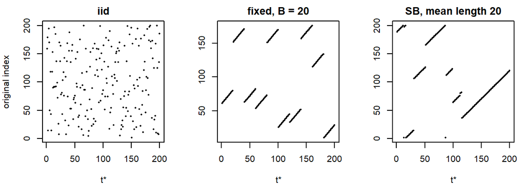

```r
plot_index <- function() {
  par(mfrow = c(1, 3), mar = c(4, 4, 2, 1))
  set.seed(123)
  plot(iid_index(200), pch = 16, cex = 0.4, main = "iid",
       xlab = "t*", ylab = "original index")
  plot(fixed_block_index(200, 20), pch = 16, cex = 0.4, main = "fixed, B = 20",
       xlab = "t*", ylab = "")
  plot(stationary_index(200, 1 / 20), pch = 16, cex = 0.4, main = "SB, mean length 20",
       xlab = "t*", ylab = "")
  par(mfrow = c(1, 1))
}

plot_index()                                          # shown in the Rmd
```

```r
#pdf("index_patterns.pdf", width = 6.5, height = 2.3)  # saved as pdf
#plot_index()
#dev.off()
```

The iid panel shows scattered points with no structure. The fixed-block panel shows straight segments of constant slope. The SB panel shows segments of varying length, because the block lengths are geometric.

#### 2.3 Autocorrelation of the resampled series

$M = 200$ bootstrap samples are drawn with $B = 20$ and $\ell = 20$ ($p_{\mathrm{sb}} = 0.05$).

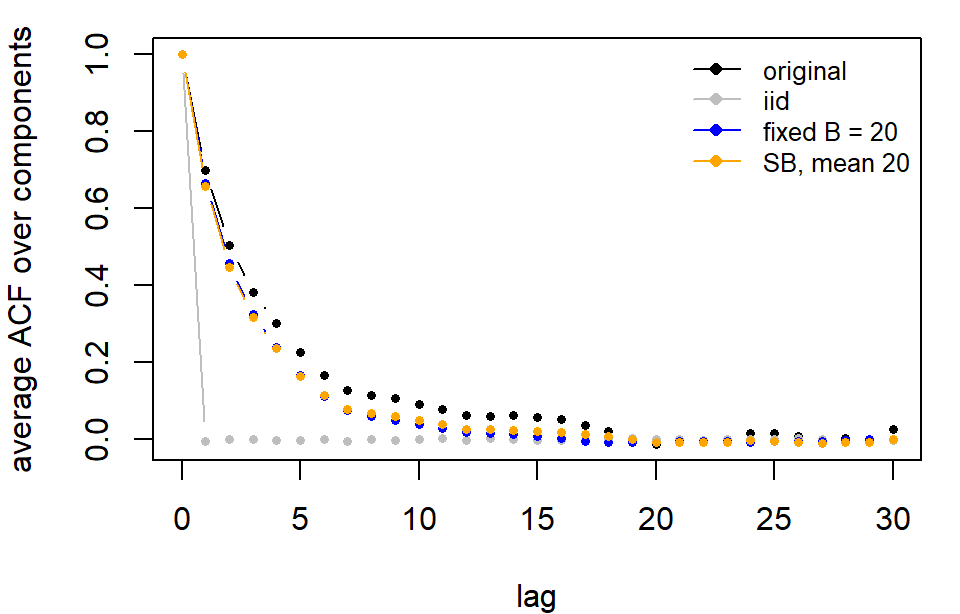

```r
M <- 200
K <- 30
ell <- 20

a_orig <- avg_acf(Xs, K)
a_iid <- boot_avg_acf(boot_samples(Xs, M, "iid"), K)
a_fixed <- boot_avg_acf(boot_samples(Xs, M, "fixed", ell), K)
a_sb <- boot_avg_acf(boot_samples(Xs, M, "stationary", 1 / ell), K)

cols <- c("black", "gray", "blue", "orange")

plot_acf_boot <- function() {
  par(mfrow = c(1, 1), mar = c(4, 4, 1, 1))
  plot(0:K, a_orig, type = "b", pch = 16, cex = 0.6, col = cols[1],
       ylim = range(c(a_orig, a_iid, a_fixed, a_sb)),
       xlab = "lag", ylab = "average ACF over components")
  lines(0:K, a_iid, type = "b", pch = 16, cex = 0.6, col = cols[2])
  lines(0:K, a_fixed, type = "b", pch = 16, cex = 0.6, col = cols[3])
  lines(0:K, a_sb, type = "b", pch = 16, cex = 0.6, col = cols[4])
  legend("topright",
         c("original", "iid", "fixed B = 20", "SB, mean 20"),
         col = cols, lty = 1, pch = 16, cex = 0.8, bty = "n")
}

plot_acf_boot()
```

```r
#pdf("bootstrap_acf.pdf", width = 5, height = 3.2)  # saved as pdf
#plot_acf_boot()
#dev.off()
```

The original series has strong serial dependence (lag-1 average ACF about $0.7$). The iid bootstrap reduces this to essentially zero at every non-zero lag. Both block methods are close to each other and lie slightly below the original ACF at the shorter lags (up to about lag 18), because the joins between consecutive blocks are usually not adjacent in the original series, so the local dependence is lost at those points. At larger lags all curves are close to zero.

#### 2.4 Effect of the block length

For each $B$ and each $\ell = B$, $M = 200$ bootstrap samples are drawn. Two summaries are reported: the average lag-1 autocorrelation over components, and the bootstrap standard deviation of the sample mean (averaged over components). The value $\ell = 1$ corresponds to the iid bootstrap.

```r
# Lag-1 ACF and SD of the sample mean over M bootstrap samples
grid_row <- function(X, method, tuning, M = 200) {
  Tn <- nrow(X); pp <- ncol(X)
  ids <- replicate(M, boot_index(Tn, method, tuning), simplify = FALSE)
  Zs <- lapply(ids, function(i) X[i, ])

  acf1_avg <- mean(sapply(Zs, function(Z) {
    a <- acf(Z, lag.max = 1, plot = FALSE)$acf
    mean(sapply(1:pp, function(j) a[2, j, j]))
  }))

  means_mat <- sapply(Zs, colMeans)
  c(acf1 = acf1_avg,
    sd_mean = mean(apply(means_mat, 1, sd)))
}

ells <- c(1, 5, 10, 20, 50, 100, 200)
fx <- t(sapply(ells, function(b) grid_row(Xs, "fixed", b)))
sb <- t(sapply(ells, function(b) grid_row(Xs, "stationary", 1 / b)))

tab <- data.frame(
  ell = ells,
  acf1_fixed = fx[, 1], acf1_SB = sb[, 1],
  sd_fixed = fx[, 2], sd_SB = sb[, 2]
)
round(tab, 3)
```

| ell | acf1_fixed | acf1_SB | sd_fixed | sd_SB |
| --- | --- | --- | --- | --- |
| 1 | -0.004 | -0.003 | 0.049 | 0.043 |
| 5 | 0.555 | 0.551 | 0.079 | 0.090 |
| 10 | 0.624 | 0.622 | 0.101 | 0.094 |
| 20 | 0.659 | 0.661 | 0.116 | 0.110 |
| 50 | 0.683 | 0.679 | 0.132 | 0.105 |
| 100 | 0.691 | 0.685 | 0.101 | 0.098 |
| 200 | 0.698 | 0.690 | 0.089 | 0.076 |

```r
cat("original lag-1 average ACF:", round(a_orig[2], 3))
```

```
## original lag-1 average ACF: 0.697
```

At $\ell = 1$ both methods reduce to iid resampling, giving an ACF of about $-0.004$ and an SD of the mean of about $0.05$. As $\ell$ increases, the lag-1 ACF rises from the iid value towards the original value of $0.697$, reaching about $0.69$ at $\ell = 200$.

The bootstrap SD of the mean peaks at moderate block lengths: around $\ell = 50$ for the fixed-block method ($0.132$) and $\ell = 20$ for the stationary bootstrap ($0.110$). For larger $\ell$ it decreases, dropping to about $0.08$ at $\ell = 200$, where only a few blocks are drawn ($T/\ell = 5$). The two methods give very similar ACF values at every $\ell$.

### 3. General check on the course data

The functions are applied to the course data `ts_data` (read in Part A) to check that they work for a general $T \times p$ matrix with $p > 2$.

```r
# A few bootstrap samples of the course data
Bd <- boot_samples(ts_data, 5, "stationary", 1 / 20)
c(n_samples = length(Bd), dim = dim(Bd[[1]]))
```

```
## n_samples      dim1      dim2
##         5      1000        10
```

```r
# Mean max deviation of the correlation matrix over N bootstrap replicates
set.seed(123)
N_corr <- 100
corr_dev <- function(method, tuning = NULL, N = N_corr) {
  mean(sapply(seq_len(N), function(n) {
    Z <- ts_data[boot_index(nrow(ts_data), method, tuning), , drop = FALSE]
    max(abs(cor(Z) - cor(ts_data)))
  }))
}

round(c(fixed      = corr_dev("fixed", 20),
        stationary = corr_dev("stationary", 1 / 20)), 3)
```

```
##      fixed stationary
##      0.076      0.075
```

The average maximum deviation of the contemporaneous correlation matrix is 0.076 (fixed-block) and 0.075 (stationary), so the bootstrap samples keep the correlation of the course data.

### 4. Summary of Part B

- Ordinary iid resampling destroys the serial dependence and is not appropriate for time series. Block-based resampling preserves the local dependence by resampling consecutive runs of observations.
- The fixed-block bootstrap resamples blocks of length $B$. The SB uses geometric block lengths with mean $\ell = 1/p_{\mathrm{sb}}$ and wraps around, which makes it conditionally stationary. Both reduce to iid resampling when $B = 1$ or $p_{\mathrm{sb}} = 1$.
- On a strongly dependent VAR(1) series, the block methods preserved the average ACF (slightly below the original values), while iid resampling did not. The bootstrap standard deviation of the mean was largest at moderate block lengths.
- The functions run on the $1000 \times 10$ course data.

## Part C: The ladle quantities

### Answer:

The function $f_0(k)$ is defined for $k=1,\dots,p-1$ as $\frac{1}{n}\sum_{j=1}^n(1-|\text{det}(\hat{B}_k^T B_{k,j}^*)|)$, where $\hat{B}_k^T$ are the first $k$ columns of the joint diagonaliser computed from the original sample and $B_{k,j}^*$ are the first $k$ columns of the joint diagonaliser computed from the $j$th bootstrap sample, and $f_0(0)=0$. The function $f(k)$ is then extracted from $f_0(k)$ by normalising in the following way: $f(k) = \frac{f_0(k)}{1 + \sum_{l=0}^{p-1} f_0(l)}$

The function $\varphi(k)$ is defined with the diagonal elements of $\Lambda$, $\lambda_0^2,\lambda_1^2,\dots,\lambda_{p-1}^2$. The diagonal elements are in a decreasing order. The (normalised) function $\varphi(k)=\lambda_k^2/(1+\sum_{l=0}^{p-1}\lambda_l^2$.

After obtaining $f$ and $\varphi$, obtaining the ladle function $g$ is easy. The ladle function is defined as $g(k) = f(k) + \varphi(k)$. The ladle estimator for the dimension will be $\hat{q} = \operatorname{arg\,min}_k \, g(k)$.

In the ladle function $g$, the information represented by the bootstrap-variability is found in the normalised variance function $f$. This is quite obvious, because it is the only quantity in $g$ that contains components stemming from bootstrapping. The variance function $f_0$ is a way of finding out the average variance of the space, which is spanned by the first $k$ vectors. The information represented by the eigenvalues is found mainly in $\varphi$, but also in $f$. The function $\varphi$ is essentially a scree plot, which contains the diagonal elements of the matrix $\varLambda$ calculated with either AMUSE or SOBI. These values are seen as eigenvalues.

Here we define the function ladle, which computes the ladle quantities $f$, $\varphi$ and $g$.

```r
ladle <- function(data, j, method, tuning, fit) {
  # Calculate f
  k <- dim(data)[2] - 1
  B_star <- list(NA)
  sd_boot <- numeric(k+1)

  if(fit == "sobi") {B_hat <- sobi_fit(data)$V}
  if(fit == "amuse") {
    X <- data
    Xc <- center_series(X)$Xc
    Xw <- whiten_series(Xc)$Xw
    M <- autocov_raw(Xw, tau = 1)
    Sigma_tau_sym <- symmetrize(M)
    B_hat <- amuse_fit(Sigma_tau_sym)$U
  }

  Bd <- boot_samples(data, j, method, tuning)

  f_0 <- matrix(rep(0,(k+1)*j), nrow = j)
#  print(f_0) # For checking if the matrix has the right dimensions

  # Conditioning based on which method is specified to be used for joint diagonalisation
  if(fit == "sobi") {
    for (i in 1:j) {
      B_star[[i]] <- sobi_fit(Bd[[i]])$V
    }
  }

  if(fit == "amuse") {
    for (i in 1:j) {
      X <- Bd[[i]]
      Xc <- center_series(X)$Xc
      Xw <- whiten_series(Xc)$Xw
      M <- autocov_raw(Xw, tau = 1)
      Sigma_tau_sym <- symmetrize(M)
      B_star[[i]] <- amuse_fit(Sigma_tau_sym)$U
    }
  }
  # Loop that calculates the matrix, which will be used for f_0
  for (m in 1:j) {
      B_star_j <- B_star[[m]]
      for (i in 1:k) {
        f_0[m,i] <- (1-abs(det(crossprod(B_hat[,1:i], B_star_j[,1:i]))))
    }
  }

  f_0 <- cbind(f_0[,k+1], f_0[,1:k])

#  print(f_0) # For checking if the first column is 0

  f_0 <- colMeans(f_0) # Actual f_0
#  f <- c(f_0[k+1], f_0[1:k])
  f <- f_0/(1 + sum(f_0))

  # Calculate phi
  l <- dim(data)[2]
  phi <- numeric(l)

  # Conditioning based on which method is specified to be used for joint diagonalisation
  if(fit == "sobi") {
    Lambda <- sobi_fit(data)$Lambda
    for (i in 1:l) {
      phi[i] <- Lambda[i]/(1+sum(Lambda))
    }
  }

  if(fit == "amuse") {
    X <- data
    Xc <- center_series(X)$Xc
    Xw <- whiten_series(Xc)$Xw
    M <- autocov_raw(Xw, tau = 1)
    Sigma_tau_sym <- symmetrize(M)
    Lambda <- amuse_fit(Sigma_tau_sym)$Lambda
    for (i in 1:l) {
      phi[i] <- Lambda[i]/(1+sum(Lambda))
    }
  }

  # Calculate g
  g <- f + phi

  return(list(f = f, phi = phi, g = g))
}
```

Simulate data to test the function.

```r
A <- matrix(c(0.8, 0.3, 0, 0.5), 2)
set.seed(7)
sim_X <- sim_var(1000, A)
sim_noise <- matrix(rnorm(2*1000), nrow = 1000)
sim_data <- cbind(sim_X, sim_noise)
```

Use the simulated data with two noise components to test the custom ladle function

```r
set.seed(8)
t_ladle1 <- ladle(sim_data, 200, "stationary", 1/40, "sobi")
t_ladle2 <- ladle(sim_data, 200, "fixed", 40, "sobi")
t_ladle3 <- ladle(sim_data, 200, "stationary", 1/40, "amuse")
t_ladle4 <- ladle(sim_data, 200, "fixed", 40, "amuse")
t_ladle5 <- ladle(sim_data, 200, "stationary", 1/60, "sobi")
t_ladle6 <- ladle(sim_data, 200, "fixed", 60, "sobi")
t_ladle7 <- ladle(sim_data, 200, "stationary", 1/60, "amuse")
t_ladle8 <- ladle(sim_data, 200, "fixed", 60, "amuse")
```

Plot the results

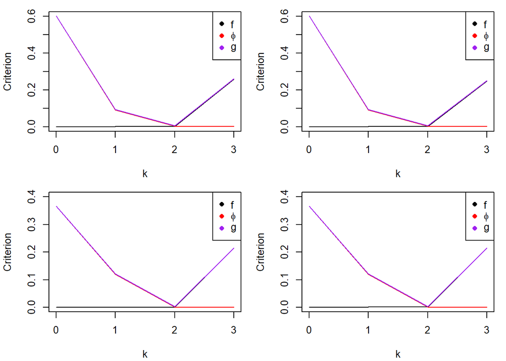

```r
exprphi <- expression(phi)
#pdf("ladle validation 1.pdf", width = 7, height = 7)
par(mfrow = c(2,2),mar = c(4.1, 4.1, 1, 1))
plot(t_ladle1$f, type = "l", xaxt = "n", ylim = c(0,.6), xlab = "k", ylab = "Criterion")
axis(1, at = seq(1,4, by = 1), labels = c("0", "1", "2", "3"))
lines(t_ladle1$phi, col = "red")
lines(t_ladle1$g, col = "purple")
legend("topright", legend = c("f", exprphi, "g"), col = c("black", "red", "purple"), pch = 16)

plot(t_ladle2$f, type = "l", xaxt = "n", ylim = c(0,.6), xlab = "k", ylab = "Criterion")
axis(1, at = seq(1,4, by = 1), labels = c("0", "1", "2", "3"))
lines(t_ladle2$phi, col = "red")
lines(t_ladle2$g, col = "purple")
legend("topright", legend = c("f", exprphi, "g"), col = c("black", "red", "purple"), pch = 16)

plot(t_ladle3$f, type = "l", xaxt = "n", ylim = c(0,.4), xlab = "k", ylab = "Criterion")
axis(1, at = seq(1,4, by = 1), labels = c("0", "1", "2", "3"))
lines(t_ladle3$phi, col = "red")
lines(t_ladle3$g, col = "purple")
legend("topright", legend = c("f", exprphi, "g"), col = c("black", "red", "purple"), pch = 16)

plot(t_ladle4$f, type = "l", xaxt = "n", ylim = c(0,.4), xlab = "k", ylab = "Criterion")
axis(1, at = seq(1,4, by = 1), labels = c("0", "1", "2", "3"))
lines(t_ladle4$phi, col = "red")
lines(t_ladle4$g, col = "purple")
legend("topright", legend = c("f", exprphi, "g"), col = c("black", "red", "purple"), pch = 16)
```

```r
#dev.off()
```

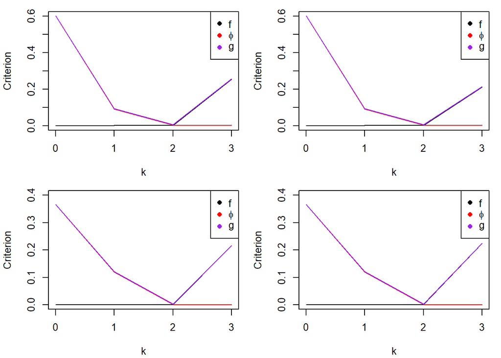

```r
#pdf("ladle validation 2.pdf", width = 7, height = 7)
par(mfrow = c(2,2),mar = c(4.1, 4.1, 1, 1))
plot(t_ladle5$f, type = "l", xaxt = "n", ylim = c(0,.6), xlab = "k", ylab = "Criterion")
axis(1, at = seq(1,4, by = 1), labels = c("0", "1", "2", "3"))
lines(t_ladle5$phi, col = "red")
lines(t_ladle5$g, col = "purple")
legend("topright", legend = c("f", exprphi, "g"), col = c("black", "red", "purple"), pch = 16)

plot(t_ladle6$f, type = "l", xaxt = "n", ylim = c(0,.6), xlab = "k", ylab = "Criterion")
axis(1, at = seq(1,4, by = 1), labels = c("0", "1", "2", "3"))
lines(t_ladle6$phi, col = "red")
lines(t_ladle6$g, col = "purple")
legend("topright", legend = c("f", exprphi, "g"), col = c("black", "red", "purple"), pch = 16)

plot(t_ladle7$f, type = "l", xaxt = "n", ylim = c(0,.4), xlab = "k", ylab = "Criterion")
axis(1, at = seq(1,4, by = 1), labels = c("0", "1", "2", "3"))
lines(t_ladle7$phi, col = "red")
lines(t_ladle7$g, col = "purple")
legend("topright", legend = c("f", exprphi, "g"), col = c("black", "red", "purple"), pch = 16)

plot(t_ladle8$f, type = "l", xaxt = "n", ylim = c(0,.4), xlab = "k", ylab = "Criterion")
axis(1, at = seq(1,4, by = 1), labels = c("0", "1", "2", "3"))
lines(t_ladle8$phi, col = "red")
lines(t_ladle8$g, col = "purple")
legend("topright", legend = c("f", exprphi, "g"), col = c("black", "red", "purple"), pch = 16)
```

```r
#dev.off()
```

All of the ladle estimators agree on that the signal dimension is 2, which is the result we hoped for.

## Part D: Simulation study

### Answer:

The simulation study will be done by using the same signal generation process as in Nordhausen & Virta, 2018. For process length, $T = 200, 500, 1000, 2000$ were considered. 10 bootstrap samples were used.

First we will define the functions that will be used to generate the signals.

```r
AR1 <- function(phi, n, burn = 200) {
  X <- numeric(n + burn)
  eps <- rnorm(n + burn)
  for (i in 2:(n + burn)) {
    X[i] <- phi * X[i-1] + eps[i]
  }
  X <- X[-(1:burn)]
  return(X)
}
```

Longer burn-in period, because there are more parameters for the more complicated models

```r
AR3 <- function(phi, n, burn = 500) {
  X <- numeric(n + burn)
  X[1:3] <- rnorm(3)
  eps <- rnorm(n + burn)
  for (i in 4:(n + burn)) {
    X[i] <- phi[1]*X[i-1] + phi[2]*X[i-2] + phi[3]*X[i-3] + eps[i]
  }
  X <- X[-(1:burn)]
  return(X)
}
```

```r
MA4 <- function(theta, n, burn = 500) {
  X <- numeric(n + burn)
  eps <- rnorm(n + burn)
  X[1:4] <- rnorm(4)
  for (i in 5:(n + burn)) {
    X[i] <- eps[i] + theta[1]*eps[i-1] + theta[2]*eps[i-2] + theta[3]*eps[i-3] + theta[4]*eps[i-4]
  }
  X <- X[-(1:burn)]
  return(X)
}
```

```r
ARMA12 <- function(phi, theta, n, burn = 500) {
  X <- numeric(n + burn)
  eps <- rnorm(n + burn)
  X[1:2] <- rnorm(2)
  for (i in 3:(n + burn)) {
    X[i] <- eps[i] + phi*X[i-1] + theta[1]*eps[i-1] + theta[2]*eps[i-2]
  }
  X <- X[-(1:burn)]
  return(X)
}
```

```r
ARMA32 <- function(phi, theta, n, burn = 500) {
  X <- numeric(n + burn)
  eps <- rnorm(n + burn)
  X[1:3] <- rnorm(3)
  for (i in 4:(n + burn)) {
    X[i] <- eps[i] + phi[1]*X[i-1] + phi[2]*X[i-2] + phi[3]*X[i-3] + theta[1]*eps[i-1] + theta[2]*eps[i-2]
  }
  X <- X[-(1:burn)]
  return(X)
}
```

Simulate the five signals and the five noise components

```r
set.seed(140)
signal1 <- ARMA12(0.6, c(0, -0.4), 2000)
signal2 <- ARMA32(c(0.4, 0.1, 0.3), c(0.2, 0.4), 2000)
signal3 <- AR1(0.4, 2000)
signal4 <- MA4(c(0.5, 0.3, 0.1, 0.2), 2000)
signal5 <- AR3(c(0.1, 0.1, 0.3), 2000)
noise <- matrix(rnorm(5*2000), nrow = 2000) # 5-variate white noise
signal <- matrix(c(signal1, signal2, signal3, signal4, signal5), nrow = 2000)

sim <- cbind(signal, noise)
```

Plot the signals

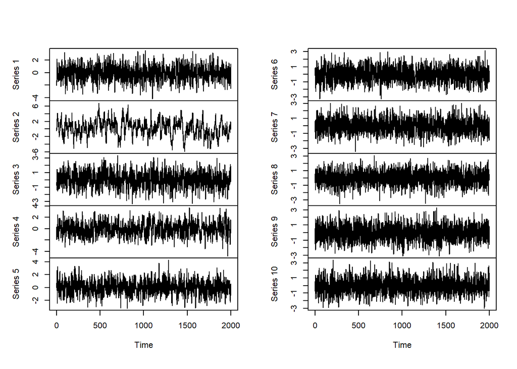

```r
plot.ts(sim, ylab = 1, main = "", cex.lab = 0.7)
```

Check the autocorrelation for the simulated time series

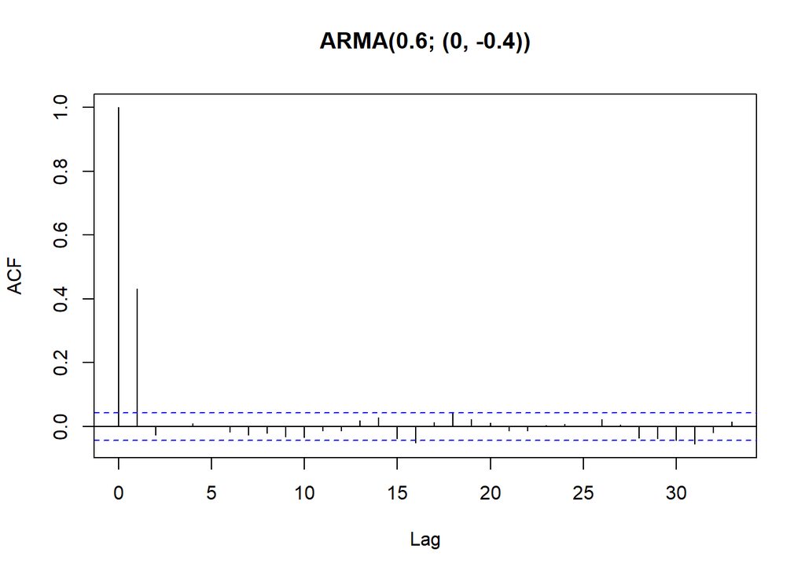

```r
acf(sim[,1], main = "ARMA(0.6; (0, -0.4))")
```

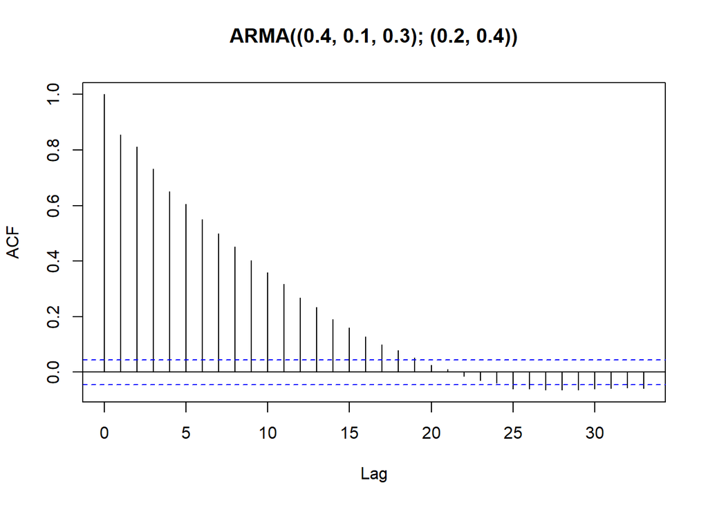

```r
acf(sim[,2], main = "ARMA((0.4, 0.1, 0.3); (0.2, 0.4))")
```

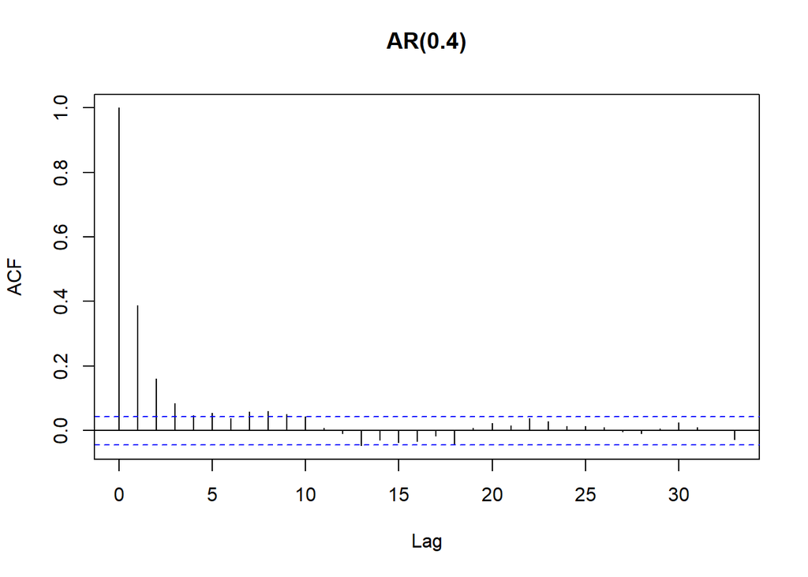

```r
acf(sim[,3], main = "AR(0.4)")
```

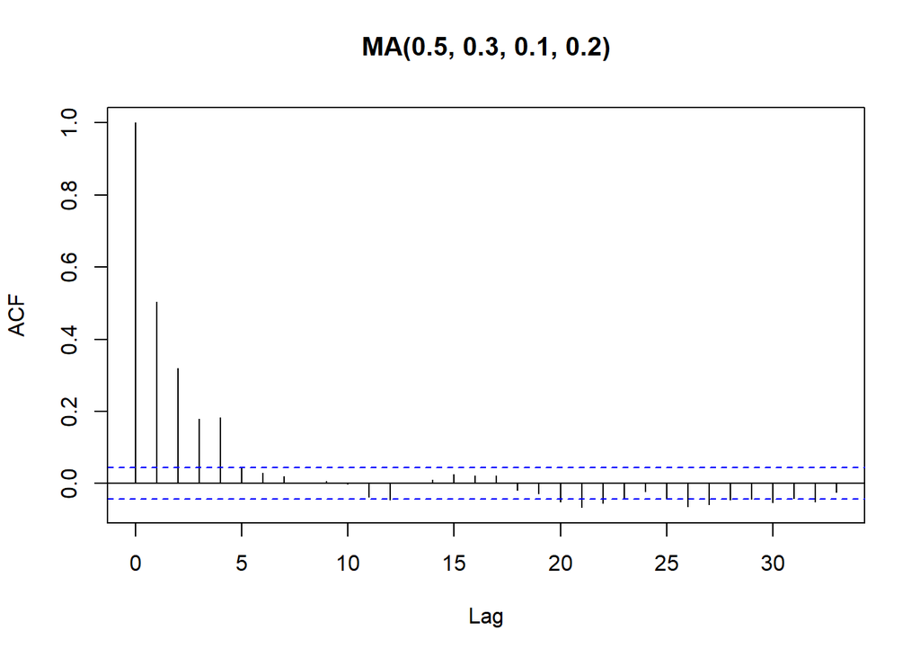

```r
acf(sim[,4], main = "MA(0.5, 0.3, 0.1, 0.2)")
```

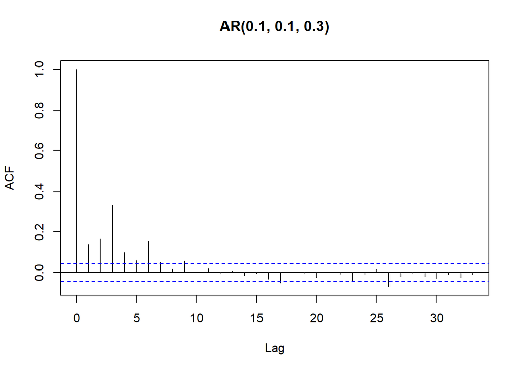

```r
acf(sim[,5], main = "AR(0.1, 0.1, 0.3)")
```

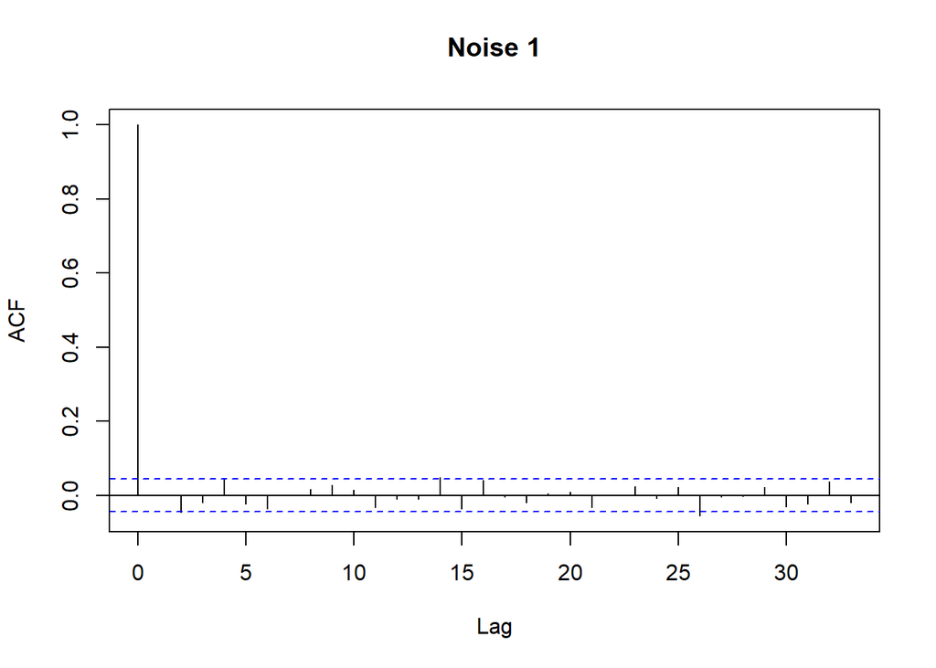

```r
acf(sim[,6], main = "Noise 1")
```

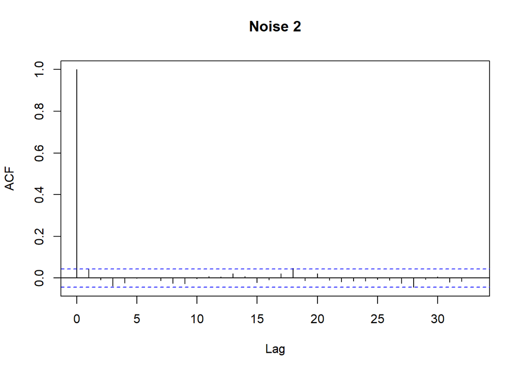

```r
acf(sim[,7], main = "Noise 2")
```

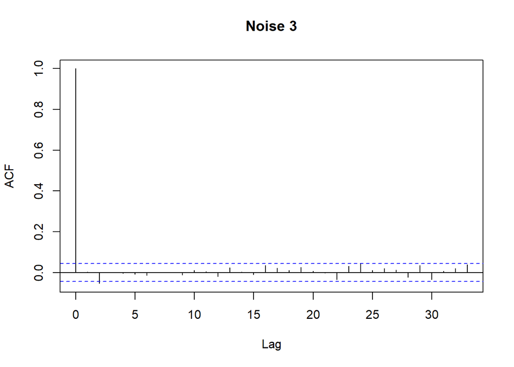

```r
acf(sim[,8], main = "Noise 3")
```

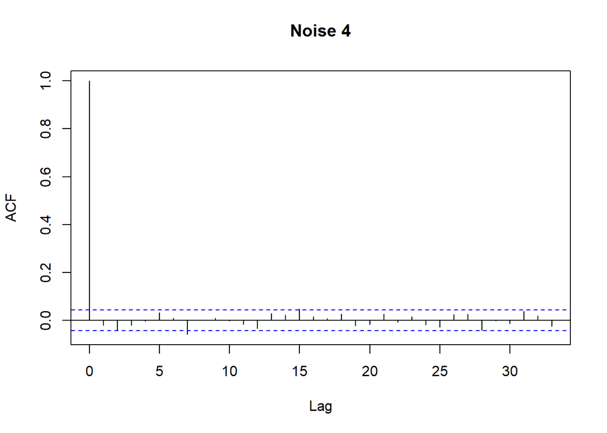

```r
acf(sim[,9], main = "Noise 4")
```

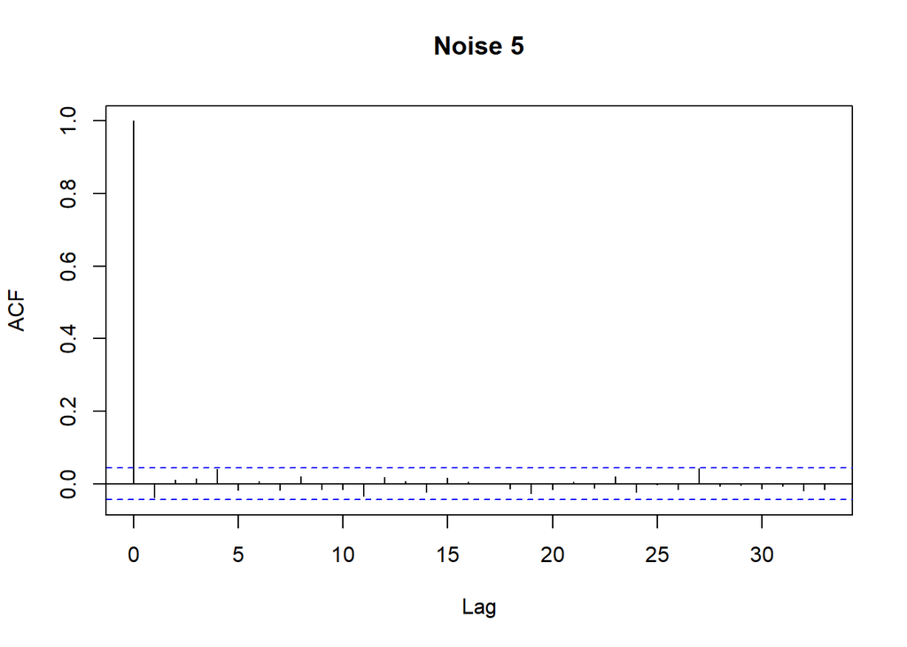

```r
acf(sim[,10], main = "Noise 5")
```

Save the time series plot as a pdf file

```r
#pdf("Simulation.pdf", width = 12, height = 5)
#plot.ts(sim, ylab = 1, main = "", cex.lab = 0.7)
#dev.off()
```

Save the autocorrelation plots as a pdf file or plot it

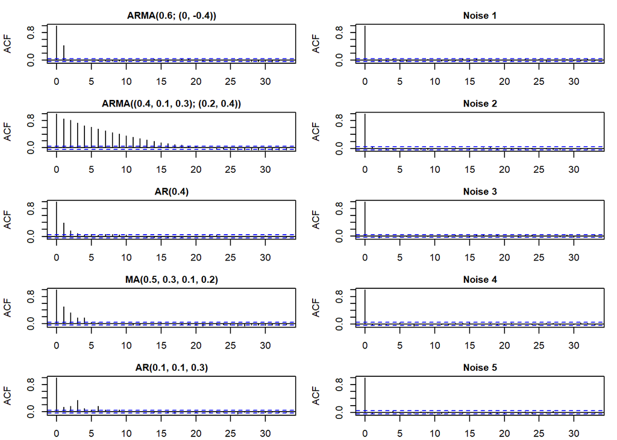

```r
titles <- c("ARMA(0.6; (0, -0.4))", "ARMA((0.4, 0.1, 0.3); (0.2, 0.4))", "AR(0.4)", "MA(0.5, 0.3, 0.1, 0.2)", "AR(0.1, 0.1, 0.3)", "Noise 1", "Noise 2", "Noise 3", "Noise 4", "Noise 5")

#pdf("Autocorrelation sim.pdf", width = 7, height = 9.33)
layout(matrix(c(1, 2, 3, 4, 5, 6, 7, 8, 9, 10), 5, 2, byrow = FALSE))

par(mar = c(2.1, 4.1, 2.1, 1.1))

for(k in 1:10){
  acf(sim[,k], main = "")
  title(titles[k], line = 0.5, cex.main = 1)
}
```

```r
#dev.off()
```

### Simulation for stationary block bootstrap with SOBI

```r
sims <- 500
min200_stationary_sobi_20 <- numeric(sims)
g200_stationary_sobi_20 <- list(NA)

min500_stationary_sobi_20 <- numeric(sims)
g500_stationary_sobi_20 <- list(NA)

min1000_stationary_sobi_20 <- numeric(sims)
g1000_stationary_sobi_20 <- list(NA)

min2000_stationary_sobi_20 <- numeric(sims)
g2000_stationary_sobi_20 <- list(NA)

start_stationary_sobi_20 <- Sys.time()
set.seed(107)
for (i in 1:sims) {
  ladle_estimates <- ladle(sim[1:200,], 10, "stationary", 1/20, "sobi")
  min200_stationary_sobi_20[i] <- which.min(ladle_estimates$g)
  g200_stationary_sobi_20[[i]] <- ladle_estimates$g
}
set.seed(106)
for (i in 1:sims) {
  ladle_estimates <- ladle(sim[1:500,], 10, "stationary", 1/20, "sobi")
  min500_stationary_sobi_20[i] <- which.min(ladle_estimates$g)
  g500_stationary_sobi_20[[i]] <- ladle_estimates$g
}
set.seed(107)
for (i in 1:sims) {
  ladle_estimates <- ladle(sim[1:1000,], 10, "stationary", 1/20, "sobi")
  min1000_stationary_sobi_20[i] <- which.min(ladle_estimates$g)
  g1000_stationary_sobi_20[[i]] <- ladle_estimates$g
}
set.seed(108)
for (i in 1:sims) {
  ladle_estimates <- ladle(sim[1:2000,], 10, "stationary", 1/20, "sobi")
  min2000_stationary_sobi_20[i] <- which.min(ladle_estimates$g)
  g2000_stationary_sobi_20[[i]] <- ladle_estimates$g
}
end_stationary_sobi_20 <- Sys.time()
```

```r
sims <- 500
min200_stationary_sobi_40 <- numeric(sims)
g200_stationary_sobi_40 <- list(NA)

min500_stationary_sobi_40 <- numeric(sims)
g500_stationary_sobi_40 <- list(NA)

min1000_stationary_sobi_40 <- numeric(sims)
g1000_stationary_sobi_40 <- list(NA)

min2000_stationary_sobi_40 <- numeric(sims)
g2000_stationary_sobi_40 <- list(NA)

start_stationary_sobi_40 <- Sys.time()
set.seed(105)
for (i in 1:sims) {
  ladle_estimates <- ladle(sim[1:200,], 10, "stationary", 1/40, "sobi")
  min200_stationary_sobi_40[i] <- which.min(ladle_estimates$g)
  g200_stationary_sobi_40[[i]] <- ladle_estimates$g
}
set.seed(106)
for (i in 1:sims) {
  ladle_estimates <- ladle(sim[1:500,], 10, "stationary", 1/40, "sobi")
  min500_stationary_sobi_40[i] <- which.min(ladle_estimates$g)
  g500_stationary_sobi_40[[i]] <- ladle_estimates$g
}

for (i in 1:sims) {
  ladle_estimates <- ladle(sim[1:1000,], 10, "stationary", 1/40, "sobi")
  min1000_stationary_sobi_40[i] <- which.min(ladle_estimates$g)
  g1000_stationary_sobi_40[[i]] <- ladle_estimates$g
}

for (i in 1:sims) {
  ladle_estimates <- ladle(sim[1:2000,], 10, "stationary", 1/40, "sobi")
  min2000_stationary_sobi_40[i] <- which.min(ladle_estimates$g)
  g2000_stationary_sobi_40[[i]] <- ladle_estimates$g
}
end_stationary_sobi_40 <- Sys.time()
```

### Simulation for stationary block bootstrap with AMUSE

```r
sims <- 500
min200_stationary_amuse_20 <- numeric(sims)
g200_stationary_amuse_20 <- list(NA)

min500_stationary_amuse_20 <- numeric(sims)
g500_stationary_amuse_20 <- list(NA)

min1000_stationary_amuse_20 <- numeric(sims)
g1000_stationary_amuse_20 <- list(NA)

min2000_stationary_amuse_20 <- numeric(sims)
g2000_stationary_amuse_20 <- list(NA)

start_stationary_amuse_20 <- Sys.time()
set.seed(107)
for (i in 1:sims) {
  ladle_estimates <- ladle(sim[1:200,], 10, "stationary", 1/20, "amuse")
  min200_stationary_amuse_20[i] <- which.min(ladle_estimates$g)
  g200_stationary_amuse_20[[i]] <- ladle_estimates$g
}
set.seed(106)
for (i in 1:sims) {
  ladle_estimates <- ladle(sim[1:500,], 10, "stationary", 1/20, "amuse")
  min500_stationary_amuse_20[i] <- which.min(ladle_estimates$g)
  g500_stationary_amuse_20[[i]] <- ladle_estimates$g
}
set.seed(107)
for (i in 1:sims) {
  ladle_estimates <- ladle(sim[1:1000,], 10, "stationary", 1/20, "amuse")
  min1000_stationary_amuse_20[i] <- which.min(ladle_estimates$g)
  g1000_stationary_amuse_20[[i]] <- ladle_estimates$g
}

for (i in 1:sims) {
  ladle_estimates <- ladle(sim[1:2000,], 10, "stationary", 1/20, "amuse")
  min2000_stationary_amuse_20[i] <- which.min(ladle_estimates$g)
  g2000_stationary_amuse_20[[i]] <- ladle_estimates$g
}
end_stationary_amuse_20 <- Sys.time()
```

```r
sims <- 500
min200_stationary_amuse_40 <- numeric(sims)
g200_stationary_amuse_40 <- list(NA)

min500_stationary_amuse_40 <- numeric(sims)
g500_stationary_amuse_40 <- list(NA)

min1000_stationary_amuse_40 <- numeric(sims)
g1000_stationary_amuse_40 <- list(NA)

min2000_stationary_amuse_40 <- numeric(sims)
g2000_stationary_amuse_40 <- list(NA)

start_stationary_amuse_40 <- Sys.time()
set.seed(105)
for (i in 1:sims) {
  ladle_estimates <- ladle(sim[1:200,], 10, "stationary", 1/40, "amuse")
  min200_stationary_amuse_40[i] <- which.min(ladle_estimates$g)
  g200_stationary_amuse_40[[i]] <- ladle_estimates$g
}
set.seed(106)
for (i in 1:sims) {
  ladle_estimates <- ladle(sim[1:500,], 10, "stationary", 1/40, "amuse")
  min500_stationary_amuse_40[i] <- which.min(ladle_estimates$g)
  g500_stationary_amuse_40[[i]] <- ladle_estimates$g
}

for (i in 1:sims) {
  ladle_estimates <- ladle(sim[1:1000,], 10, "stationary", 1/40, "amuse")
  min1000_stationary_amuse_40[i] <- which.min(ladle_estimates$g)
  g1000_stationary_amuse_40[[i]] <- ladle_estimates$g
}

for (i in 1:sims) {
  ladle_estimates <- ladle(sim[1:2000,], 10, "stationary", 1/40, "amuse")
  min2000_stationary_amuse_40[i] <- which.min(ladle_estimates$g)
  g2000_stationary_amuse_40[[i]] <- ladle_estimates$g
}
end_stationary_amuse_40 <- Sys.time()
```

### Simulation for fixed block bootstrap with SOBI

```r
sims <- 500
min200_fixed_sobi_20 <- numeric(sims)
g200_fixed_sobi_20 <- list(NA)

min500_fixed_sobi_20 <- numeric(sims)
g500_fixed_sobi_20 <- list(NA)

min1000_fixed_sobi_20 <- numeric(sims)
g1000_fixed_sobi_20 <- list(NA)

min2000_fixed_sobi_20 <- numeric(sims)
g2000_fixed_sobi_20 <- list(NA)

start_fixed_sobi_20 <- Sys.time()
set.seed(107)
for (i in 1:sims) {
  ladle_estimates <- ladle(sim[1:200,], 10, "fixed", 20, "sobi")
  min200_fixed_sobi_20[i] <- which.min(ladle_estimates$g)
  g200_fixed_sobi_20[[i]] <- ladle_estimates$g
}
set.seed(106)
for (i in 1:sims) {
  ladle_estimates <- ladle(sim[1:500,], 10, "fixed", 20, "sobi")
  min500_fixed_sobi_20[i] <- which.min(ladle_estimates$g)
  g500_fixed_sobi_20[[i]] <- ladle_estimates$g
}
set.seed(107)
for (i in 1:sims) {
  ladle_estimates <- ladle(sim[1:1000,], 10, "fixed", 20, "sobi")
  min1000_fixed_sobi_20[i] <- which.min(ladle_estimates$g)
  g1000_fixed_sobi_20[[i]] <- ladle_estimates$g
}
set.seed(108)
for (i in 1:sims) {
  ladle_estimates <- ladle(sim[1:2000,], 10, "fixed", 20, "sobi")
  min2000_fixed_sobi_20[i] <- which.min(ladle_estimates$g)
  g2000_fixed_sobi_20[[i]] <- ladle_estimates$g
}
end_fixed_sobi_20 <- Sys.time()
```

```r
sims <- 500
min200_fixed_sobi_40 <- numeric(sims)
g200_fixed_sobi_40 <- list(NA)

min500_fixed_sobi_40 <- numeric(sims)
g500_fixed_sobi_40 <- list(NA)

min1000_fixed_sobi_40 <- numeric(sims)
g1000_fixed_sobi_40 <- list(NA)

min2000_fixed_sobi_40 <- numeric(sims)
g2000_fixed_sobi_40 <- list(NA)

start_fixed_sobi_40 <- Sys.time()
set.seed(105)
for (i in 1:sims) {
  ladle_estimates <- ladle(sim[1:200,], 10, "fixed", 40, "sobi")
  min200_fixed_sobi_40[i] <- which.min(ladle_estimates$g)
  g200_fixed_sobi_40[[i]] <- ladle_estimates$g
}
set.seed(106)
for (i in 1:sims) {
  ladle_estimates <- ladle(sim[1:500,], 10, "fixed", 40, "sobi")
  min500_fixed_sobi_40[i] <- which.min(ladle_estimates$g)
  g500_fixed_sobi_40[[i]] <- ladle_estimates$g
}

for (i in 1:sims) {
  ladle_estimates <- ladle(sim[1:1000,], 10, "fixed", 40, "sobi")
  min1000_fixed_sobi_40[i] <- which.min(ladle_estimates$g)
  g1000_fixed_sobi_40[[i]] <- ladle_estimates$g
}

for (i in 1:sims) {
  ladle_estimates <- ladle(sim[1:2000,], 10, "fixed", 40, "sobi")
  min2000_fixed_sobi_40[i] <- which.min(ladle_estimates$g)
  g2000_fixed_sobi_40[[i]] <- ladle_estimates$g
}
end_fixed_sobi_40 <- Sys.time()
```

### Simulation for fixed block bootstrap with AMUSE

```r
sims <- 500
min200_fixed_amuse_20 <- numeric(sims)
g200_fixed_amuse_20 <- list(NA)

min500_fixed_amuse_20 <- numeric(sims)
g500_fixed_amuse_20 <- list(NA)

min1000_fixed_amuse_20 <- numeric(sims)
g1000_fixed_amuse_20 <- list(NA)

min2000_fixed_amuse_20 <- numeric(sims)
g2000_fixed_amuse_20 <- list(NA)

start_fixed_amuse_20 <- Sys.time()
set.seed(107)
for (i in 1:sims) {
  ladle_estimates <- ladle(sim[1:200,], 10, "fixed", 20, "amuse")
  min200_fixed_amuse_20[i] <- which.min(ladle_estimates$g)
  g200_fixed_amuse_20[[i]] <- ladle_estimates$g
}
set.seed(106)
for (i in 1:sims) {
  ladle_estimates <- ladle(sim[1:500,], 10, "fixed", 20, "amuse")
  min500_fixed_amuse_20[i] <- which.min(ladle_estimates$g)
  g500_fixed_amuse_20[[i]] <- ladle_estimates$g
}
set.seed(107)
for (i in 1:sims) {
  ladle_estimates <- ladle(sim[1:1000,], 10, "fixed", 20, "amuse")
  min1000_fixed_amuse_20[i] <- which.min(ladle_estimates$g)
  g1000_fixed_amuse_20[[i]] <- ladle_estimates$g
}

for (i in 1:sims) {
  ladle_estimates <- ladle(sim[1:2000,], 10, "fixed", 20, "amuse")
  min2000_fixed_amuse_20[i] <- which.min(ladle_estimates$g)
  g2000_fixed_amuse_20[[i]] <- ladle_estimates$g
}
end_fixed_amuse_20 <- Sys.time()
```

```r
sims <- 500
min200_fixed_amuse_40 <- numeric(sims)
g200_fixed_amuse_40 <- list(NA)

min500_fixed_amuse_40 <- numeric(sims)
g500_fixed_amuse_40 <- list(NA)

min1000_fixed_amuse_40 <- numeric(sims)
g1000_fixed_amuse_40 <- list(NA)

min2000_fixed_amuse_40 <- numeric(sims)
g2000_fixed_amuse_40 <- list(NA)

start_fixed_amuse_40 <- Sys.time()
set.seed(105)
for (i in 1:sims) {
  ladle_estimates <- ladle(sim[1:200,], 10, "fixed", 40, "amuse")
  min200_fixed_amuse_40[i] <- which.min(ladle_estimates$g)
  g200_fixed_amuse_40[[i]] <- ladle_estimates$g
}
set.seed(106)
for (i in 1:sims) {
  ladle_estimates <- ladle(sim[1:500,], 10, "fixed", 40, "amuse")
  min500_fixed_amuse_40[i] <- which.min(ladle_estimates$g)
  g500_fixed_amuse_40[[i]] <- ladle_estimates$g
}

for (i in 1:sims) {
  ladle_estimates <- ladle(sim[1:1000,], 10, "fixed", 40, "amuse")
  min1000_fixed_amuse_40[i] <- which.min(ladle_estimates$g)
  g1000_fixed_amuse_40[[i]] <- ladle_estimates$g
}

for (i in 1:sims) {
  ladle_estimates <- ladle(sim[1:2000,], 10, "fixed", 40, "amuse")
  min2000_fixed_amuse_40[i] <- which.min(ladle_estimates$g)
  g2000_fixed_amuse_40[[i]] <- ladle_estimates$g
}
end_fixed_amuse_40 <- Sys.time()
```

Calculate the computation times for each method and the total amount of time used

```r
data.frame(SOBI_S_20 = end_stationary_sobi_20 - start_stationary_sobi_20,
           SOBI_S_40 = end_stationary_sobi_40 - start_stationary_sobi_40,
           SOBI_F_20 = end_fixed_sobi_20 - start_fixed_sobi_20,
           SOBI_F_40 = end_fixed_sobi_40 - start_fixed_sobi_40,
           AMUSE_S_20 = end_stationary_amuse_20 - start_stationary_amuse_20,
           AMUSE_S_40 = end_stationary_amuse_40 - start_stationary_amuse_40,
           AMUSE_F_20 = end_fixed_amuse_20 - start_fixed_amuse_20,
           AMUSE_F_40 = end_fixed_amuse_40 - start_fixed_amuse_40,
           total_time = end_stationary_sobi_20 - start_stationary_sobi_20 + end_stationary_sobi_40 - start_stationary_sobi_40 + end_fixed_sobi_20 - start_fixed_sobi_20 + end_fixed_sobi_40 - start_fixed_sobi_40 + end_stationary_amuse_20 - start_stationary_amuse_20 + end_stationary_amuse_40 - start_stationary_amuse_40 + end_fixed_amuse_20 - start_fixed_amuse_20 +  end_fixed_amuse_40 - start_fixed_amuse_40)
```

| SOBI_S_20 | SOBI_S_40 | SOBI_F_20 | SOBI_F_40 | AMUSE_S_20 | AMUSE_S_40 | AMUSE_F_20 | AMUSE_F_40 | total_time |
| --- | --- | --- | --- | --- | --- | --- | --- | --- |
| 16.86851 mins | 17.24433 mins | 17.23366 mins | 18.37249 mins | 11.76926 secs | 11.61668 secs | 10.68972 secs | 10.75876 secs | 1.174437 hours |

Function that preps the variables with the minimums for plotting

```r
barplot_prep <- function(data, dimension) {
  x <- numeric(dimension)
  for (i in 1:dimension) {
    x[i] <- sum(data-1 == i)
  }
  return(matrix(x, nrow = dimension))
}
```

Barplots will be used to visualise the proportions of estimated signal dimensions for each method and signal length.

Save the barplots of the minimums as a pdf file or plot them

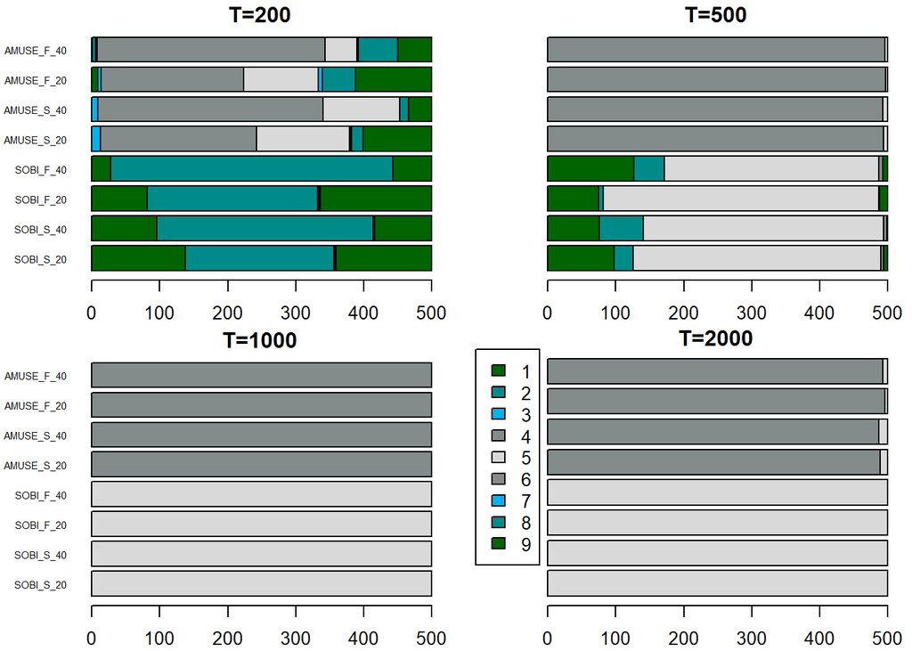

```r
#pdf("Simulated ladle estimates.pdf", width = 7, height = 7)
par(mar=c(2.1, 4.1, 1.3, 1.1), mfrow = c(2, 2))
colour <- c("darkgreen", "darkcyan","deepskyblue2", "azure4", "grey85", "azure4", "deepskyblue2", "darkcyan", "darkgreen")

barplot(matrix(c(barplot_prep(min200_stationary_sobi_20, 10),
barplot_prep(min200_stationary_sobi_40, 10),
barplot_prep(min200_fixed_sobi_20, 10),
barplot_prep(min200_fixed_sobi_40, 10),
barplot_prep(min200_stationary_amuse_20, 10),
barplot_prep(min200_stationary_amuse_40, 10),
barplot_prep(min200_fixed_amuse_20, 10),
barplot_prep(min200_fixed_amuse_40, 10)), nrow = 10) , col = colour, names.arg = c("SOBI_S_20", "SOBI_S_40", "SOBI_F_20", "SOBI_F_40", "AMUSE_S_20", "AMUSE_S_40", "AMUSE_F_20", "AMUSE_F_40"), horiz = T, las = 1, cex.names = 0.55, main = "T=200")

barplot(matrix(c(barplot_prep(min500_stationary_sobi_20, 10),
barplot_prep(min500_stationary_sobi_40, 10),
barplot_prep(min500_fixed_sobi_20, 10),
barplot_prep(min500_fixed_sobi_40, 10),
barplot_prep(min500_stationary_amuse_20, 10),
barplot_prep(min500_stationary_amuse_40, 10),
barplot_prep(min500_fixed_amuse_20, 10),
barplot_prep(min500_fixed_amuse_40, 10)), nrow = 10) , col = colour, horiz = T, las = 1, cex.names = 0.55, main = "T=500")

barplot(matrix(c(barplot_prep(min1000_stationary_sobi_20, 10),
barplot_prep(min1000_stationary_sobi_40, 10),
barplot_prep(min1000_fixed_sobi_20, 10),
barplot_prep(min1000_fixed_sobi_40, 10),
barplot_prep(min1000_stationary_amuse_20, 10),
barplot_prep(min1000_stationary_amuse_40, 10),
barplot_prep(min1000_fixed_amuse_20, 10),
barplot_prep(min1000_fixed_amuse_40, 10)), nrow = 10) , col = colour, names.arg = c("SOBI_S_20", "SOBI_S_40", "SOBI_F_20", "SOBI_F_40", "AMUSE_S_20", "AMUSE_S_40", "AMUSE_F_20", "AMUSE_F_40"), horiz = T, las = 1, cex.names = 0.55, main = "T=1000")

par(mar=c(2.1, 4.1, 1.1, 1.1), xpd = TRUE)
barplot(matrix(c(barplot_prep(min2000_stationary_sobi_20, 10),
barplot_prep(min2000_stationary_sobi_40, 10),
barplot_prep(min2000_fixed_sobi_20, 10),
barplot_prep(min2000_fixed_sobi_40, 10),
barplot_prep(min2000_stationary_amuse_20, 10),
barplot_prep(min2000_stationary_amuse_40, 10),
barplot_prep(min2000_fixed_amuse_20, 10),
barplot_prep(min2000_fixed_amuse_40, 10)), nrow = 10) , col = colour, horiz = T, las = 1, cex.names = 0.55, main = "T=2000")

legend("topleft", inset = c(-0.2,0.0), c("1", "2", "3", "4", "5", "6", "7", "8", "9"), cex = 1, fill = colour)
```

```r
#dev.off()
```

Calculate Monte Carlo variability

Start by converting all lists into matrices to prep for plotting

```r
g200_stationary_sobi_20_mat <- do.call(rbind, g200_stationary_sobi_20)
g500_stationary_sobi_20_mat <- do.call(rbind, g500_stationary_sobi_20)
g1000_stationary_sobi_20_mat <- do.call(rbind, g1000_stationary_sobi_20)
g2000_stationary_sobi_20_mat <- do.call(rbind, g2000_stationary_sobi_20)
```

```r
g200_stationary_sobi_40_mat <- do.call(rbind, g200_stationary_sobi_40)
g500_stationary_sobi_40_mat <- do.call(rbind, g500_stationary_sobi_40)
g1000_stationary_sobi_40_mat <- do.call(rbind, g1000_stationary_sobi_40)
g2000_stationary_sobi_40_mat <- do.call(rbind, g2000_stationary_sobi_40)
```

```r
g200_stationary_amuse_20_mat <- do.call(rbind, g200_stationary_amuse_20)
g500_stationary_amuse_20_mat <- do.call(rbind, g500_stationary_amuse_20)
g1000_stationary_amuse_20_mat <- do.call(rbind, g1000_stationary_amuse_20)
g2000_stationary_amuse_20_mat <- do.call(rbind, g2000_stationary_amuse_20)
```

```r
g200_stationary_amuse_40_mat <- do.call(rbind, g200_stationary_amuse_40)
g500_stationary_amuse_40_mat <- do.call(rbind, g500_stationary_amuse_40)
g1000_stationary_amuse_40_mat <- do.call(rbind, g1000_stationary_amuse_40)
g2000_stationary_amuse_40_mat <- do.call(rbind, g2000_stationary_amuse_40)
```

```r
g200_fixed_sobi_20_mat <- do.call(rbind, g200_fixed_sobi_20)
g500_fixed_sobi_20_mat <- do.call(rbind, g500_fixed_sobi_20)
g1000_fixed_sobi_20_mat <- do.call(rbind, g1000_fixed_sobi_20)
g2000_fixed_sobi_20_mat <- do.call(rbind, g2000_fixed_sobi_20)
```

```r
g200_fixed_sobi_40_mat <- do.call(rbind, g200_fixed_sobi_40)
g500_fixed_sobi_40_mat <- do.call(rbind, g500_fixed_sobi_40)
g1000_fixed_sobi_40_mat <- do.call(rbind, g1000_fixed_sobi_40)
g2000_fixed_sobi_40_mat <- do.call(rbind, g2000_fixed_sobi_40)
```

```r
g200_fixed_amuse_20_mat <- do.call(rbind, g200_fixed_amuse_20)
g500_fixed_amuse_20_mat <- do.call(rbind, g500_fixed_amuse_20)
g1000_fixed_amuse_20_mat <- do.call(rbind, g1000_fixed_amuse_20)
g2000_fixed_amuse_20_mat <- do.call(rbind, g2000_fixed_amuse_20)
```

```r
g200_fixed_amuse_40_mat <- do.call(rbind, g200_fixed_amuse_40)
g500_fixed_amuse_40_mat <- do.call(rbind, g500_fixed_amuse_40)
g1000_fixed_amuse_40_mat <- do.call(rbind, g1000_fixed_amuse_40)
g2000_fixed_amuse_40_mat <- do.call(rbind, g2000_fixed_amuse_40)
```

Save the boxplots of the row means of the ladle function for each setting as a pdf file or plot them

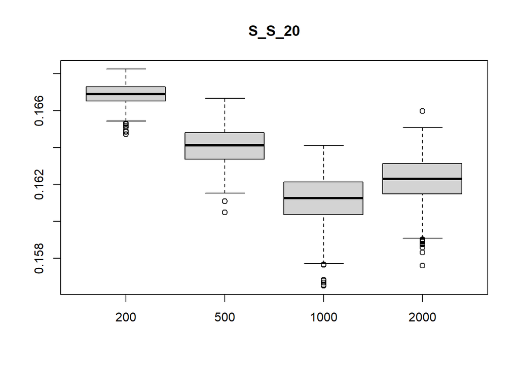

```r
#pdf("mc variability.pdf", width = 7, height = 7)
#par(mfrow = c(3, 3), mar = c(3, 3, 2, 1) + 0.1)
boxplot(rowMeans(g200_stationary_sobi_20_mat), rowMeans(g500_stationary_sobi_20_mat), rowMeans(g1000_stationary_sobi_20_mat), rowMeans(g2000_stationary_sobi_20_mat), names = c("200", "500", "1000", "2000"), main = "S_S_20")
```

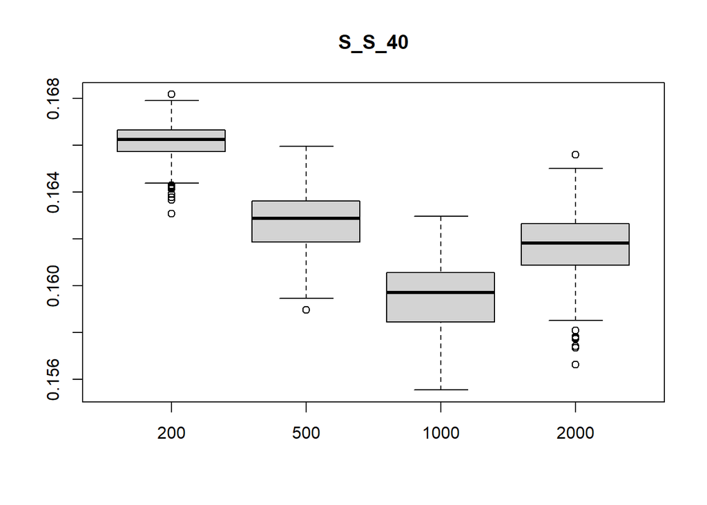

```r
boxplot(rowMeans(g200_stationary_sobi_40_mat), rowMeans(g500_stationary_sobi_40_mat), rowMeans(g1000_stationary_sobi_40_mat), rowMeans(g2000_stationary_sobi_40_mat), names = c("200", "500", "1000", "2000"), main = "S_S_40")
```

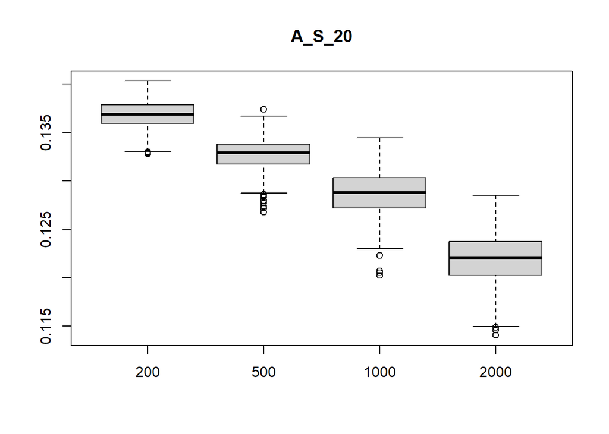

```r
boxplot(rowMeans(g200_stationary_amuse_20_mat), rowMeans(g500_stationary_amuse_20_mat), rowMeans(g1000_stationary_amuse_20_mat), rowMeans(g2000_stationary_amuse_20_mat), names = c("200", "500", "1000", "2000"), main = "A_S_20")
```

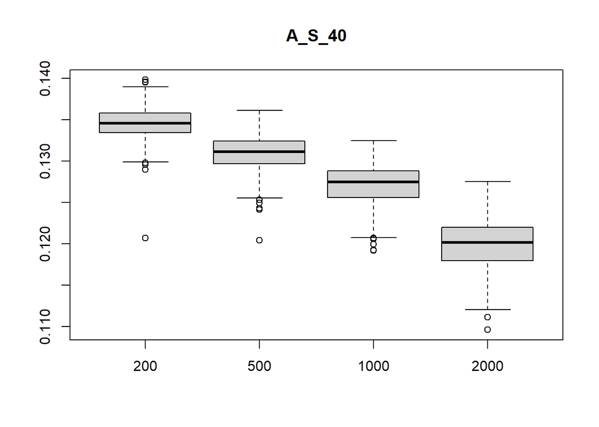

```r
boxplot(rowMeans(g200_stationary_amuse_40_mat), rowMeans(g500_stationary_amuse_40_mat), rowMeans(g1000_stationary_amuse_40_mat), rowMeans(g2000_stationary_amuse_40_mat), names = c("200", "500", "1000", "2000"), main = "A_S_40")
```

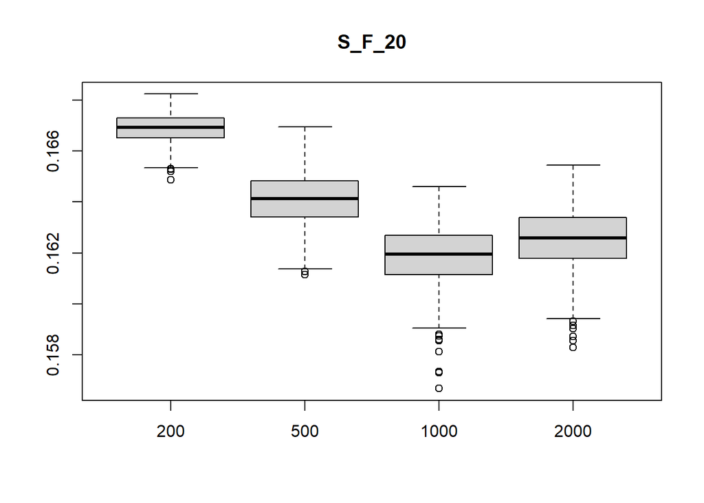

```r
boxplot(rowMeans(g200_fixed_sobi_20_mat), rowMeans(g500_fixed_sobi_20_mat), rowMeans(g1000_fixed_sobi_20_mat), rowMeans(g2000_fixed_sobi_20_mat), names = c("200", "500", "1000", "2000"), main = "S_F_20")
```

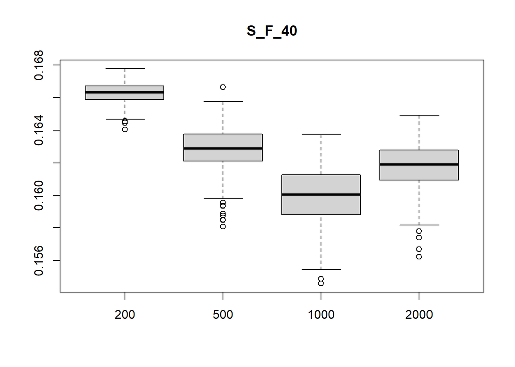

```r
boxplot(rowMeans(g200_fixed_sobi_40_mat), rowMeans(g500_fixed_sobi_40_mat), rowMeans(g1000_fixed_sobi_40_mat), rowMeans(g2000_fixed_sobi_40_mat), names = c("200", "500", "1000", "2000"), main = "S_F_40")
```

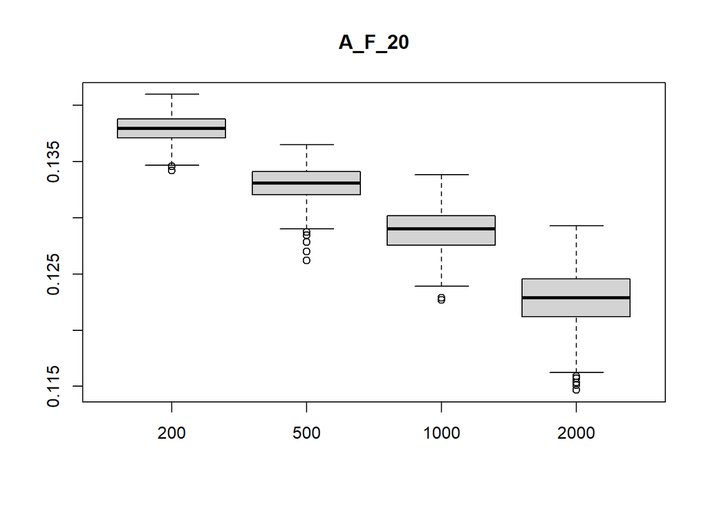

```r
boxplot(rowMeans(g200_fixed_amuse_20_mat), rowMeans(g500_fixed_amuse_20_mat), rowMeans(g1000_fixed_amuse_20_mat), rowMeans(g2000_fixed_amuse_20_mat), names = c("200", "500", "1000", "2000"), main = "A_F_20")
```

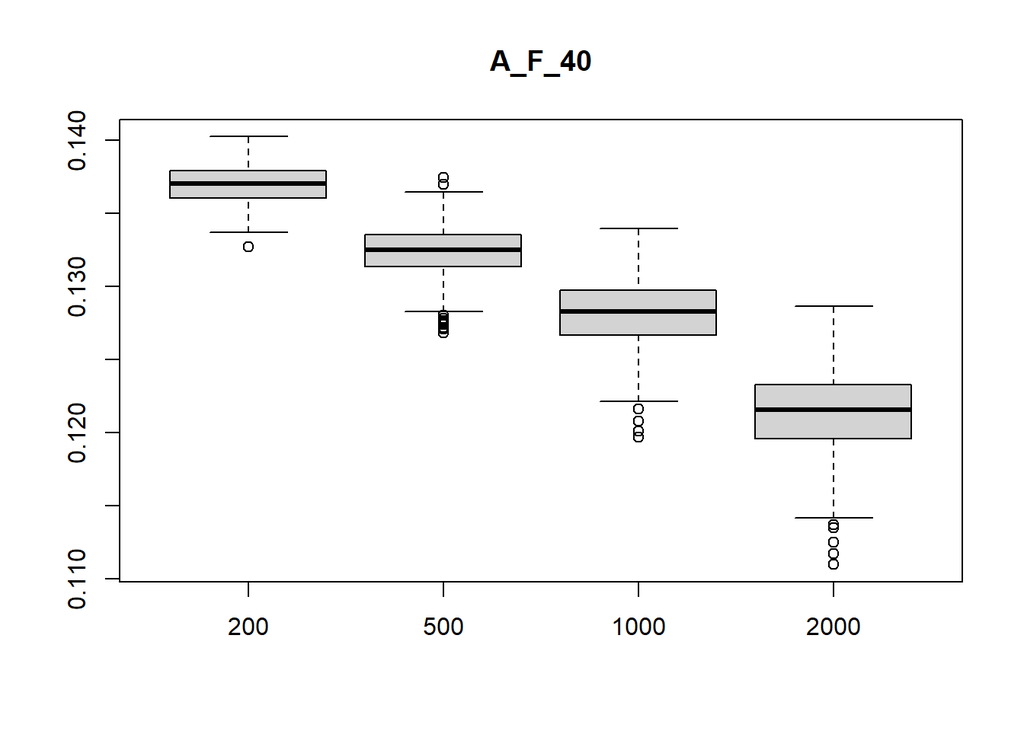

```r
boxplot(rowMeans(g200_fixed_amuse_40_mat), rowMeans(g500_fixed_amuse_40_mat), rowMeans(g1000_fixed_amuse_40_mat), rowMeans(g2000_fixed_amuse_40_mat), names = c("200", "500", "1000", "2000"), main = "A_F_40")
```

```r
#dev.off()
```

## Part E: Application to the course data

### Answer:

Calculate the ladle quantities for timeseries.dat for four different settings

```r
set.seed(456)
ts_ladle <- ladle(ts_data, 100, "fixed", 20, "sobi")
ts_ladle2 <- ladle(ts_data, 100, "fixed", 40, "sobi")
ts_ladle3 <- ladle(ts_data, 100, "stationary", 1/20, "sobi")
ts_ladle4 <- ladle(ts_data, 100, "stationary", 1/40, "sobi")
```

Plot the ladle plots or save the ladle plots as a pdf file

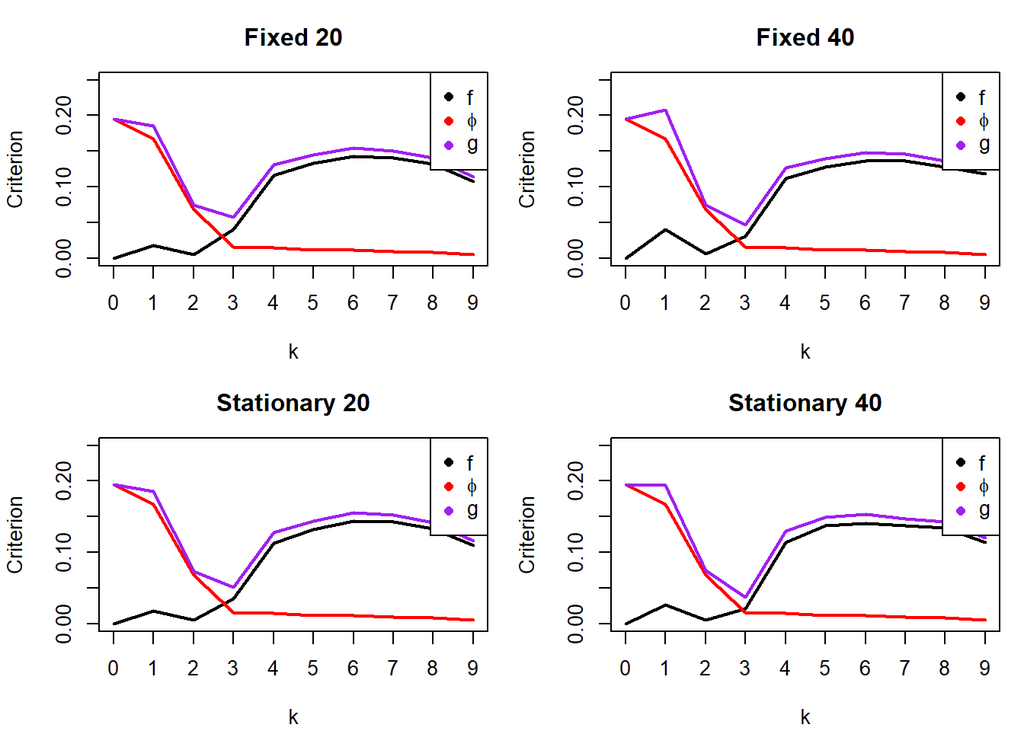

```r
#pdf("Ladle estimates ts.pdf", width = 7, height = 7)
par(mar = c(4.1, 4.1, 3, 1), mfrow = c(2, 2))
plot(ts_ladle$f, type = "l", xaxt = "n", ylim = c(0,.25), xlab = "k", ylab = "Criterion", lwd = 2, main = "Fixed 20")
axis(1, at = seq(1, 10, by = 1), labels = c("0", "1", "2", "3", "4", "5", "6", "7", "8", "9"))
lines(ts_ladle$phi, col = "red", lwd = 2)
lines(ts_ladle$g, col = "purple", lwd = 2)
legend("topright", legend = c("f", exprphi, "g"), col = c("black", "red", "purple"), pch = 16)

plot(ts_ladle2$f, type = "l", xaxt = "n", ylim = c(0,.25), xlab = "k", ylab = "Criterion", lwd = 2, main = "Fixed 40")
axis(1, at = seq(1, 10, by = 1), labels = c("0", "1", "2", "3", "4", "5", "6", "7", "8", "9"))
lines(ts_ladle2$phi, col = "red", lwd = 2)
lines(ts_ladle2$g, col = "purple", lwd = 2)
legend("topright", legend = c("f", exprphi, "g"), col = c("black", "red", "purple"), pch = 16)

plot(ts_ladle3$f, type = "l", xaxt = "n", ylim = c(0,.25), xlab = "k", ylab = "Criterion", lwd = 2, main = "Stationary 20")
axis(1, at = seq(1, 10, by = 1), labels = c("0", "1", "2", "3", "4", "5", "6", "7", "8", "9"))
lines(ts_ladle3$phi, col = "red", lwd = 2)
lines(ts_ladle3$g, col = "purple", lwd = 2)
legend("topright", legend = c("f", exprphi, "g"), col = c("black", "red", "purple"), pch = 16)

plot(ts_ladle4$f, type = "l", xaxt = "n", ylim = c(0,.25), xlab = "k", ylab = "Criterion", lwd = 2, main = "Stationary 40")
axis(1, at = seq(1, 10, by = 1), labels = c("0", "1", "2", "3", "4", "5", "6", "7", "8", "9"))
lines(ts_ladle4$phi, col = "red", lwd = 2)
lines(ts_ladle4$g, col = "purple", lwd = 2)
legend("topright", legend = c("f", exprphi, "g"), col = c("black", "red", "purple"), pch = 16)
```

```r
#dev.off()
```

### Plots and summaries for timeseries.dat

# Plots and summaries for timeseries.dat

Plot timeseries.dat or save as a pdf file

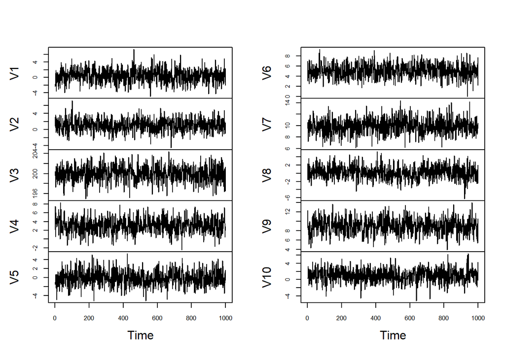

```r
#pdf("Time series data.pdf", width = 10, height = 5)
plot.ts(ts_data, cex.axis = 0.8, main = "")
```

```r
#dev.off()
```

Print the summary

```r
summary(ts_data)
```

```
##        V1                V2                 V3              V4
##  Min.   :-5.0071   Min.   :-4.52743   Min.   :194.9   Min.   :-2.478
##  1st Qu.:-0.8049   1st Qu.: 0.03594   1st Qu.:199.0   1st Qu.: 1.984
##  Median : 0.3956   Median : 1.08825   Median :200.0   Median : 3.111
##  Mean   : 0.4107   Mean   : 1.08284   Mean   :200.0   Mean   : 3.120
##  3rd Qu.: 1.6022   3rd Qu.: 2.11793   3rd Qu.:200.9   3rd Qu.: 4.266
##  Max.   : 7.3002   Max.   : 7.22986   Max.   :204.4   Max.   : 8.328
##        V5                 V6                 V7               V8
##  Min.   :-5.19772   Min.   :-0.04155   Min.   : 6.131   Min.   :-6.2542
##  1st Qu.:-1.14065   1st Qu.: 4.18474   1st Qu.: 9.054   1st Qu.:-0.9057
##  Median :-0.08298   Median : 5.11403   Median : 9.940   Median : 0.1357
##  Mean   :-0.06225   Mean   : 5.10583   Mean   : 9.932   Mean   : 0.1800
##  3rd Qu.: 0.98839   3rd Qu.: 6.02194   3rd Qu.:10.838   3rd Qu.: 1.1979
##  Max.   : 5.29669   Max.   : 9.27851   Max.   :14.433   Max.   : 5.3416
##        V9              V10
##  Min.   : 3.938   Min.   :-5.22249
##  1st Qu.: 7.875   1st Qu.:-0.01815
##  Median : 9.041   Median : 1.04182
##  Mean   : 9.024   Mean   : 1.03488
##  3rd Qu.:10.047   3rd Qu.: 2.12268
##  Max.   :14.002   Max.   : 6.33180
```

# Task 2: Bayesian mixture modelling with MCMC

$$\mu_1,\mu_2\overset{\mathrm{ind}}{\sim}N(m_0,s_0^2)$$
The standardized observations have a sample mean of $0$ and a sample variance of $1$. So we choose $m_0 = 0$, because the observations are centred around zero after standardization.

The prior standard deviation $s_0$ have to choose how widely we think the component means can vary around $m_0$. For example, suppose we believe that the component means lie within the interval $[-10,10]$. We can choose $s_0 = 5$, giving the prior distribution $\mu_1,\mu_2 \overset{\mathrm{ind}}{\sim} N(0,5^2)$ For a normal distribution, the approximate 95% prior interval is
$$\begin{aligned}
[m_0 - 1.96s_0,\; m_0 + 1.96s_0]
&= [0 - 1.96(5),\; 0 + 1.96(5)] \\
&= [-9.80,\; 9.80].
\end{aligned}$$
Therefore, this prior assigns approximately 95% probability to each component mean being between $-9.80$ and $9.80$.
$$\pi\sim\operatorname{Beta}(a,b)$$
$0<\pi<1$, therefore all values have to be between 0 and 1. if the prior distribution is beta, then the obvious choice is ${Beta}(1,1)$, which is a uniform prior.

$$\sigma^2\sim\operatorname{InvGamma}(\alpha_0,\beta_0)$$
Because the standardized data have overall variance 1, by taking $\sigma^2\sim\operatorname{InvGamma}(2,1)$, which means $\alpha_0=2$ and $\beta_0=1$, gives $E(\sigma^2)=1$
$$E(\sigma^2)=\frac{\beta_0}{\alpha_0-1}=\frac{1}{2-1}=1$$
Also, with shape 2, the inverse-Gamma distribution has substantial uncertainty, including a heavy right tail.

## Part A: Latent-variable representation and Gibbs sampler

1. Conditional distribution of $Z_i$

Objective is to find the full conditional distribution of $Z_i$, given $y_i$, $\mu_1$, $\mu_2$, $\pi$, and $\sigma^2$.

The two-component Gaussian mixture model is

$$Y_i\mid Z_i=k\sim N(\mu_k,\sigma^2),
\qquad k\in\{1,2\}$$

Therefore, for component 1,

$$Y_i\mid Z_i=1\sim N(\mu_1,\sigma^2)$$
$$P(Z_i=1)=\pi$$

and for component 2,

$$Y_i\mid Z_i=2\sim N(\mu_2,\sigma^2)$$
$$P(Z_i=2)=1-\pi$$

Using the multiplication rule,

$$f(y_i,z_i)=f(y_i\mid z_i)P(Z_i=z_i)$$

if $Z_i = 1$:
$$f(y_i,z_i=1)=\pi f_1(y_i)
\tag{1}$$

if $Z_i = 2$:
$$f(y_i,z_i=2)=(1-\pi)f_2(y_i)
\tag{2}$$

For $n$ observations, let $n_1$ denote the number of observations allocated to component 1 and $n_2$ denote the number allocated to component 2.

Then,

$$n_1+n_2=n$$

Complete likelihood
$$f(y,z)
=
\pi^{n_1}(1-\pi)^{n_2}
\prod_{i:z_i=1}f_1(y_i)
\prod_{i:z_i=2}f_2(y_i)$$

From Bayes’ theorem,
$$P(Z_i=1\mid y_i)
=
\frac{f(y_i,Z_i=1)}{f(y_i)}
\tag{3}$$

Total probability,
$$\begin{aligned}
f(y_i)
&=f(y_i,Z_i=1)+f(y_i,Z_i=2)\\
&=\pi f_1(y_i)+(1-\pi)f_2(y_i)
\end{aligned}
\tag{4}$$

Substituting (1) and (4) into (3),

$$\boxed{
P(Z_i=1\mid y_i)
=
\frac{\pi f_1(y_i)}
{\pi f_1(y_i)+(1-\pi)f_2(y_i)}
}$$

Similarly,

$$\boxed{
P(Z_i=2\mid y_i)
=
\frac{(1-\pi)f_2(y_i)}
{\pi f_1(y_i)+(1-\pi)f_2(y_i)}
}$$

2. Conditional distribution of $\mu_1$ and $\mu_2$

First, consider the conditional distribution of $\mu_1$.

Objective is to find

$$f(\mu_1\mid y,z,\sigma^2)$$

The prior distribution is

$$\mu_1\sim N(m_0,s_0^2)$$

From Bayes’ theorem,
$$f(\mu_1\mid y,z,\sigma^2)
\propto
f(y\mid z,\mu_1,\sigma^2)f(\mu_1)
\tag{5}$$

The normal prior density is
$$f(\mu_1)
=
\frac{1}{\sqrt{2\pi_{\mathrm{math}}s_0^2}}
\exp\left(
-\frac{(\mu_1-m_0)^2}{2s_0^2}
\right)$$
Ignoring constants that do not depend on $\mu_1$,
$$f(\mu_1)
\propto
\exp\left(
-\frac{(\mu_1-m_0)^2}{2s_0^2}
\right)
\tag{6}$$

The likelihood contains only observations allocated to component 1.

Therefore,

$$f(y\mid z,\mu_1,\sigma^2)
\propto
\prod_{i:z_i=1}
\exp\left(
-\frac{(y_i-\mu_1)^2}{2\sigma^2}
\right)$$
$$f(y\mid z,\mu_1,\sigma^2)
\propto
\exp\left(
-\frac{\sum_{i:z_i=1}(y_i-\mu_1)^2}
{2\sigma^2}
\right)
\tag{7}$$

Substituting (6) and (7) into (5),

$$f(\mu_1\mid y,z,\sigma^2)
\propto
\exp\left(
-\frac{\sum_{i:z_i=1}(y_i-\mu_1)^2}
{2\sigma^2}
\right)
\times
\exp\left(
-\frac{(\mu_1-m_0)^2}{2s_0^2}
\right)$$

Combining the exponential terms,

$$f(\mu_1\mid y,z,\sigma^2)
\propto
\exp\left[
-\frac12
\left(
\frac{\sum_{i:z_i=1}(y_i-\mu_1)^2}{\sigma^2}
+
\frac{(\mu_1-m_0)^2}{s_0^2}
\right)
\right]$$

Expanding the squared terms,

$$\begin{aligned}
\sum_{i:z_i=1}(y_i-\mu_1)^2
&=
\sum_{i:z_i=1}y_i^2
-2\mu_1\sum_{i:z_i=1}y_i
+n_1\mu_1^2
\end{aligned}$$

and

$$(\mu_1-m_0)^2
=
\mu_1^2-2\mu_1m_0+m_0^2$$

Removing terms that do not depend on $\mu_1$,

$$f(\mu_1\mid y,z,\sigma^2)
\propto
\exp\Bigg[
-\left(
\frac{n_1}{2\sigma^2}
+\frac{1}{2s_0^2}
\right)\mu_1^2
+
\left(
\frac{\sum_{i:z_i=1}y_i}{\sigma^2}
+\frac{m_0}{s_0^2}
\right)\mu_1
\Bigg]
\tag{8}$$

Normal density can be written as
$$\begin{aligned}
f(x)
&\propto
\exp\left(
-\frac{(x-m)^2}{2v}
\right)
\\
&\propto
\exp\left(
-\frac{x^2-2xm+m^2}{2v}
\right)
\end{aligned}$$
$$f(x)
\propto
\exp\left(
-\frac{x^2}{2v}+\frac{m}{v}x
\right)
\tag{9}$$

Comparing (8) and (9), we obtain

$$\frac{1}{2v_1}
=
\frac{n_1}{2\sigma^2}
+
\frac{1}{2s_0^2}$$

Therefore,

$$\boxed{
v_1=
\left(
\frac{n_1}{\sigma^2}
+
\frac{1}{s_0^2}
\right)^{-1}
}$$

Similarly,

$$\frac{m_1}{v_1}
=
\frac{\sum_{i:z_i=1}y_i}{\sigma^2}
+
\frac{m_0}{s_0^2}$$

Therefore,

$$\boxed{
m_1=
v_1
\left(
\frac{\sum_{i:z_i=1}y_i}{\sigma^2}
+
\frac{m_0}{s_0^2}
\right)
}$$

The conditional distribution for $\mu_1$,
$$\boxed{
\mu_1\mid y,z,\sigma^2
\sim N(m_1,v_1)
}$$

Similarly, for $\mu_2$,
$$\boxed{
\mu_2\mid y,z,\sigma^2
\sim N(m_2,v_2)
}$$

where
$$\boxed{
v_2=
\left(
\frac{n_2}{\sigma^2}
+
\frac{1}{s_0^2}
\right)^{-1}
}$$

and
$$\boxed{
m_2=
v_2
\left(
\frac{\sum_{i:z_i=2}y_i}{\sigma^2}
+
\frac{m_0}{s_0^2}
\right)
}$$

3. Conditional distribution of $\pi$

Objective is
$$f(\pi\mid z)$$

We know that

$$P(Z_i=1)=\pi
\qquad
P(Z_i=2)=1-\pi$$

Prior distribution

$$\pi\sim\operatorname{Beta}(a,b)$$

Beta density
$$f(\pi)\propto
\pi^{a-1}(1-\pi)^{b-1}
\tag{10}$$

Likelihood

$$f(z\mid\pi)
=
\pi^{n_1}(1-\pi)^{n_2}
\tag{11}$$

From Bayes’ theorem,

$$f(\pi\mid z)
\propto
f(z\mid\pi)f(\pi)$$

Substituting (10) and (11),

$$\begin{aligned}
f(\pi\mid z)
&\propto
\pi^{n_1}(1-\pi)^{n_2}
\times
\pi^{a-1}(1-\pi)^{b-1}
\\
&\propto
\pi^{n_1+a-1}(1-\pi)^{n_2+b-1}
\end{aligned}$$

Therefore,

$$\boxed{
\pi\mid z
\sim
\operatorname{Beta}(a+n_1,b+n_2)
}$$

4. Conditional distribution of $\sigma^2$

Objective is conditional distribution of the variance $\sigma^2$

Prior distribution
$$\sigma^2
\sim
\operatorname{InvGamma}(\alpha_0,\beta_0)$$

Inverse-Gamma density
$$f(\sigma^2)
\propto
(\sigma^2)^{-(\alpha_0+1)}
\exp\left(
-\frac{\beta_0}{\sigma^2}
\right)
\tag{12}$$

Likelihood
$$f(y\mid z,\mu_1,\mu_2,\sigma^2)
\propto
(\sigma^2)^{-n/2}
\exp\left[
-\frac{
\sum_{i=1}^{n}(y_i-\mu_{z_i})^2
}{2\sigma^2}
\right]
\tag{13}$$
Where,
$$\mu_{z_i}
=
\begin{cases}
\mu_1, & z_i=1\\
\mu_2, & z_i=2
\end{cases}$$

From Bayes’ theorem,

$$f(\sigma^2\mid y,z,\mu_1,\mu_2)
\propto
f(y\mid z,\mu_1,\mu_2,\sigma^2)
f(\sigma^2)$$

Substituting (12) and (13),

$$f(\sigma^2\mid\cdots)
\propto
(\sigma^2)^{-n/2}
\exp\left[
-\frac{
\sum_{i=1}^{n}(y_i-\mu_{z_i})^2
}{2\sigma^2}
\right]
\times
(\sigma^2)^{-(\alpha_0+1)}
\exp\left(
-\frac{\beta_0}{\sigma^2}
\right)$$

Combining the powers and exponential terms,

$$f(\sigma^2\mid\cdots)
\propto
(\sigma^2)^{-(\alpha_0+n/2+1)}
\times
\exp\left[
-\frac{
\beta_0+
\frac12\sum_{i=1}^{n}(y_i-\mu_{z_i})^2
}{\sigma^2}
\right]$$

This is the kernel of an inverse-Gamma distribution.

Therefore,

$$\boxed{
\sigma^2\mid y,z,\mu_1,\mu_2
\sim
\operatorname{InvGamma}
\left(
\alpha_0+\frac{n}{2},
\beta_0+
\frac12\sum_{i=1}^{n}(y_i-\mu_{z_i})^2
\right)
}$$

Funtion: Input Meaning y: Observed data n_iter: Number of stored MCMC states, including the initial state m0: Prior mean of $\mu_1,\mu_2$ s0: Prior standard deviation of the means a, b: Beta prior hyperparameters alpha0, beta0: Inverse-Gamma prior hyperparameters mu1_init: Starting value for $\mu_1$ mu2_init: Starting value for $\mu_2$ pi_init: Starting value for $\pi$ sigma2_init: Starting value for $\sigma^2$

```r
#Gibbs sampler


gibbs_sampler <- function(y, n_iter = 12000,
                          m0 = 0, s0 = 5,
                          a = 1, b = 1,
                          alpha0 = 2, beta0 = 1,
                          mu1_init = -1,
                          mu2_init = 1,
                          pi_init = 0.5,
                          sigma2_init = 1) {

  n <- length(y)

  # Store posterior draws
  mu1 <- numeric(n_iter)
  mu2 <- numeric(n_iter)
  pi <- numeric(n_iter)
  sigma2 <- numeric(n_iter)

  # Store latent allocations
  Z <- matrix(NA_integer_, nrow = n_iter, ncol = n)

  # Initial parameter values
  mu1[1] <- mu1_init
  mu2[1] <- mu2_init
  pi[1] <- pi_init
  sigma2[1] <- sigma2_init

  # Initial allocations
  Z[1, ] <- ifelse(y < (mu1_init + mu2_init)/2, 1L, 2L)

  for (t in 2:n_iter) {

    ##########################################
    # (a): Update Z_i
    ##########################################

    #Calculate the log density for component 1
    log_f1 <- dnorm(
      y, mean = mu1[t-1],
      sd = sqrt(sigma2[t-1]),
      log = TRUE
    )

    ##Calculate the log density for component 2
    log_f2 <- dnorm(
      y, mean = mu2[t-1],
      sd = sqrt(sigma2[t-1]),
      log = TRUE
    )

    # Conditional probability of component 1 (P(Z=1|y))
    w <- plogis(
      log(pi[t-1]) + log_f1 -
      log1p(-pi[t-1]) - log_f2
    )

    Z[t, ] <- ifelse(runif(n) < w, 1L, 2L) #if P(Z|y)<pi, assigned to 1L, otherwise assigned to 2L

    z <- Z[t, ]

    n1 <- sum(z == 1)
    n2 <- sum(z == 2)

    ##########################################
    # (b1): Update mu1
    ##########################################

    v1 <- 1 / (n1 / sigma2[t-1] + 1 / s0^2) #conditional variance
    m1 <- v1 * ((sum(y[z == 1]) / sigma2[t-1]) + (m0 / s0^2)) #conditional mean

    mu1[t] <- rnorm(1, mean = m1, sd = sqrt(v1)) #Generate a new value for \(\mu_1\)

    ##########################################
    # (b2): Update mu2
    ##########################################

    v2 <- 1 / (n2 / sigma2[t-1] + 1 / s0^2) #conditional variance
    m2 <- v2 * ((sum(y[z == 2]) / sigma2[t-1]) +(m0 / s0^2)) #conditional mean

    mu2[t] <- rnorm(1, mean = m2, sd = sqrt(v2)) #Generate a new value for \(\mu_2\)

    ##########################################
    # (c): Update pi
    ##########################################

    pi[t] <- rbeta(1, shape1 = a + n1, shape2 = b + n2)

    ##########################################
    # Step 5: Update sigma2
    ##########################################

    mu_z <- ifelse(z == 1, mu1[t], mu2[t]) #assign mean corresponding to each observation
    alpha_n <- alpha0 + n / 2
    beta_n <- beta0 + 0.5 * sum((y - mu_z)^2)

    # Inverse-Gamma random variable
    sigma2[t] <- 1 / rgamma(1, shape = alpha_n, rate = beta_n)
  }

  return(list(draws = data.frame(mu1, mu2, pi, sigma2), Z = Z))
}
```